# lab5

Tsvetkov Alex

22.11.2020

## Подготовительные действия

```r
library(ggplot2)
library(factoextra)
library(dplyr)
library(resample)
library(kableExtra)
library(psych)
library(gridExtra)
path <- "C:\\R\\lab5\\nut_dataframe.csv"

df <- read.csv(path, fileEncoding = "UTF-8", stringsAsFactors = FALSE)
df <- na.omit(df[, -1])
```

Подготовленный dataframe:

```r
kable(df) %>%
  kable_styling("striped", full_width = F) %>%
  scroll_box(width = "100%", height = "400px")
```

| Germ | GBegF | BegFEndF | EndFBegM | BegMEndM | Height | Hlp | NoPodsWeight | PodsWeight | PodsNumber | SeedsNumber | SeedsWeight | PodLength | PodWidth | Seed1000W | FloCol | StemCol | BushShape | LeafSize | FlowStemCol | AscoRes | StemBr | StemL1ord | StemBr1ord | StemBr2ord | PodD | PodS | PodShape | SeedShape | SeedCol |
| --- | --- | --- | --- | --- | --- | --- | --- | --- | --- | --- | --- | --- | --- | --- | --- | --- | --- | --- | --- | --- | --- | --- | --- | --- | --- | --- | --- | --- | --- |
| -2.1289902 | -0.9808181 | 0.2691854 | -0.1585673 | -1.0883455 | 0.7900028 | 0.5494152 | 0.7037179 | 0.7337723 | 0.7159398 | 1.0494188 | 0.7284773 | -0.7355614 | -1.2360736 | -0.9465373 | 2 | 1 | 0 | 0 | 1 | 3 | 2 | 1 | 1 | 0 | 0 | 0 | 1 | 0 | 1 |
| -2.1289902 | -0.6495050 | 0.2691854 | -0.1585673 | -1.7436236 | 0.6776419 | -0.5445412 | 0.7527438 | 0.8547601 | 0.9299394 | 1.4442088 | 0.8600099 | -0.3928084 | -1.2360736 | -0.2990235 | 2 | 1 | 0 | 1 | 1 | 2 | 2 | 1 | 1 | 0 | 0 | 1 | 1 | 0 | 1 |
| -2.1289902 | -0.6495050 | 0.2691854 | -0.9909240 | 0.8774887 | 0.4529201 | -0.5445412 | 0.3609298 | 0.4388255 | 0.0589700 | 0.6238324 | 0.4231896 | -0.3928084 | -0.6873112 | -0.5237654 | 2 | 1 | 0 | 1 | 1 | 2 | 2 | 1 | 1 | 0 | 0 | 1 | 1 | 0 | 1 |
| -2.1289902 | 0.6757476 | -0.5464464 | -0.4003575 | -0.4330675 | 0.6776419 | 0.9869978 | 0.7633832 | 0.1432029 | -0.0439034 | 0.3139857 | 0.2980390 | 0.2926974 | -0.1385489 | -0.1591038 | 2 | 1 | 0 | 1 | 1 | 3 | 1 | 1 | 1 | 0 | 0 | 1 | 1 | 0 | 1 |
| -2.1289902 | -1.3121313 | 0.4461669 | -0.4003575 | -1.0883455 | -0.3336062 | 0.5494152 | -0.8607554 | -0.1032154 | -0.4840317 | -0.2213891 | -0.3174326 | -1.0783143 | -0.6873112 | -0.8564317 | 2 | 1 | 0 | 1 | 1 | 1 | 3 | 0 | 1 | 1 | 0 | 1 | 1 | 0 | 1 |
| -2.1289902 | -0.9808181 | 0.6145117 | -0.9909240 | 1.5327668 | 0.1158374 | -0.5445412 | -0.2002730 | 0.7816652 | 0.8047384 | 1.0346461 | 0.3725953 | -1.4210672 | -0.6873112 | -1.3410172 | 2 | 1 | 0 | 1 | 1 | 1 | 3 | 1 | 1 | 1 | 1 | 1 | 1 | 0 | 2 |
| -2.1289902 | -0.6495050 | 0.4461669 | -0.9909240 | 1.5327668 | 0.2281983 | -0.5445412 | 0.1465487 | 0.0385432 | 0.1243058 | 0.7382824 | 0.3089732 | -0.7355614 | -1.2360736 | -1.1364654 | 2 | 2 | 0 | 0 | 1 | 1 | 3 | 0 | 1 | 1 | 0 | 1 | 1 | 0 | 1 |
| -2.1289902 | -1.6434444 | 0.7750235 | -0.6744766 | 1.2051278 | -0.1088844 | -0.5445412 | -0.2706904 | -0.3503861 | -0.2302328 | 0.4551810 | -0.1012362 | -0.7355614 | -1.2360736 | -1.1364654 | 2 | 1 | 0 | 0 | 1 | 1 | 2 | 0 | 1 | 0 | 0 | 1 | 1 | 0 | 1 |
| -2.1289902 | 0.6757476 | -0.5464464 | -0.6744766 | 1.2051278 | 2.1383336 | 1.6433716 | 0.5120401 | -0.2311678 | -0.8932663 | -0.0836431 | -0.3357660 | 1.3209562 | 0.4102134 | -0.4467205 | 2 | 2 | 0 | 1 | 1 | 1 | 2 | 0 | 1 | 0 | 0 | 1 | 1 | 0 | 1 |
| 0.1167331 | -0.6495050 | 0.0826328 | -0.1585673 | -1.0883455 | -0.3336062 | -1.2009150 | -0.6158670 | 0.9154720 | 0.4717055 | 1.4879573 | 1.0518942 | -0.3928084 | -0.6873112 | -0.6031104 | 2 | 2 | 0 | 1 | 1 | 1 | 3 | 1 | 1 | 1 | 0 | 1 | 1 | 0 | 2 |
| -2.1289902 | -0.6495050 | 0.0826328 | -1.8232807 | 1.5327668 | 0.1158374 | -0.7633324 | -0.2467764 | -0.0215593 | 0.1243058 | 0.5629262 | 0.0823344 | -1.0783143 | -1.2360736 | -0.2281430 | 2 | 2 | 0 | 1 | 1 | 1 | 3 | 1 | 1 | 1 | 0 | 1 | 1 | 0 | 1 |
| 0.1167331 | -1.6434444 | 0.4461669 | -0.9909240 | -0.1054284 | -1.0077716 | -2.0760801 | -0.6000750 | 0.8278350 | 1.2422149 | 1.6505284 | 0.8248735 | -0.7355614 | -1.2360736 | -1.0398052 | 2 | 2 | 0 | 1 | 1 | 2 | 2 | 1 | 1 | 0 | 0 | 1 | 1 | 0 | 1 |
| 0.1167331 | -1.3121313 | 0.0826328 | -1.3652017 | -0.1054284 | -1.0077716 | -2.0760801 | -0.2002730 | 0.6890852 | 1.2422149 | 1.3524186 | 0.6153626 | -1.0783143 | -1.2360736 | -1.4495164 | 2 | 2 | 0 | 1 | 1 | 1 | 3 | 1 | 1 | 0 | 0 | 1 | 1 | 0 | 1 |
| -2.1289902 | -1.3121313 | 0.4461669 | -0.9909240 | -0.1054284 | -0.4459671 | 0.9869978 | -1.3224146 | -1.1416094 | -1.5107395 | -0.3740543 | -1.1090796 | -0.3928084 | -1.2360736 | -1.0398052 | 2 | 2 | 0 | 1 | 1 | 1 | 1 | 0 | 0 | 0 | 0 | 0 | 1 | 0 | 2 |
| -2.1289902 | -0.9808181 | 0.4461669 | -0.6744766 | -0.1054284 | -1.0077716 | -0.3257499 | -0.5092802 | -0.2106333 | -0.0795994 | 0.1570712 | -0.3543793 | -1.4210672 | -1.2360736 | -0.6848972 | 2 | 2 | 0 | 1 | 1 | 1 | 3 | 1 | 1 | 0 | 0 | 0 | 1 | 0 | 2 |
| -2.1289902 | 0.6757476 | -0.3237638 | -0.9909240 | 1.5327668 | 0.6776419 | -0.7633324 | 0.1551772 | -0.0572111 | 0.1872652 | 0.2635955 | -0.0711323 | -0.7355614 | -0.1385489 | -0.7692809 | 2 | 1 | 0 | 1 | 1 | 2 | 2 | 1 | 0 | 0 | 0 | 0 | 1 | 0 | 2 |
| -2.1289902 | -0.9808181 | 0.4461669 | -0.1585673 | -0.4330675 | -0.4459671 | -0.1069586 | -0.5239640 | -0.3849186 | 0.7385701 | 0.7011546 | 0.3198101 | -0.3928084 | -1.2360736 | -0.8564317 | 2 | 1 | 0 | 1 | 1 | 1 | 3 | 0 | 1 | 1 | 1 | 0 | 1 | 0 | 2 |
| 0.1167331 | -0.9808181 | 0.0826328 | -0.4003575 | -0.1054284 | -0.4459671 | -2.0760801 | -0.5538570 | 0.8368730 | 1.3717103 | 1.6600930 | 0.9660896 | -1.0783143 | -1.7848359 | -1.3410172 | 2 | 1 | 1 | 0 | 1 | 2 | 3 | 0 | 1 | 1 | 0 | 0 | 1 | 0 | 1 |
| 0.1167331 | -1.9747575 | 0.6145117 | 0.4319992 | -0.1054284 | 0.1158374 | -0.1069586 | -0.4522046 | -0.6003740 | -0.3524855 | -0.1856714 | -0.3924808 | -0.7355614 | -0.1385489 | -0.2281430 | 2 | 1 | 1 | 1 | 1 | 1 | 3 | 0 | 1 | 1 | 1 | 1 | 1 | 0 | 2 |
| 0.1167331 | 2.9949396 | -1.9454564 | -0.1585673 | 1.2051278 | -0.4459671 | -0.7633324 | 0.4249609 | 0.5220369 | 1.2082689 | 0.9105419 | 0.1708088 | -1.0783143 | -0.6873112 | -0.8564317 | 2 | 1 | 1 | 0 | 1 | 1 | 3 | 0 | 1 | 1 | 0 | 0 | 1 | 0 | 1 |
| -2.1289902 | -1.3121313 | 0.4461669 | 0.0577215 | -0.7607065 | -1.5695761 | -1.2009150 | -1.2948212 | -1.4227389 | -0.8932663 | -0.6393538 | -0.9771513 | -1.4210672 | -1.7848359 | -1.6807806 | 2 | 2 | 1 | 0 | 1 | 1 | 2 | 1 | 1 | 0 | 0 | 0 | 1 | 0 | 1 |
| -2.1289902 | -1.3121313 | 0.2691854 | -0.4003575 | -0.4330675 | -0.4459671 | 0.5494152 | -0.6810998 | -0.0392614 | -0.1160469 | 0.4326081 | -0.1165716 | -0.3928084 | -0.1385489 | -1.0398052 | 2 | 2 | 1 | 1 | 1 | 1 | 1 | 0 | 1 | 0 | 0 | 0 | 1 | 0 | 2 |
| -2.1289902 | -0.6495050 | 0.0826328 | -0.1585673 | -0.4330675 | -0.1088844 | 0.9869978 | -0.9404931 | -0.2004879 | -0.0439034 | 0.2635955 | 0.0149610 | -0.3928084 | -0.1385489 | -0.5237654 | 2 | 2 | 1 | 1 | 1 | 2 | 2 | 1 | 1 | 0 | 0 | 1 | 1 | 0 | 1 |
| -2.1289902 | 0.3444345 | 0.7750235 | 0.5963144 | 0.2222106 | 0.1158374 | 0.9869978 | -0.4947662 | -0.6003740 | -0.4840317 | 0.2377089 | 0.0823344 | -0.3928084 | -1.2360736 | -0.5237654 | 2 | 1 | 1 | 1 | 1 | 2 | 2 | 1 | 1 | 0 | 1 | 1 | 1 | 0 | 1 |
| -2.1289902 | -0.6495050 | 0.0826328 | -0.4003575 | -0.4330675 | 0.2281983 | 0.7682065 | -0.3976113 | 0.0045443 | 0.3067052 | 0.5835218 | 0.1949511 | -1.0783143 | -1.2360736 | -0.6031104 | 2 | 1 | 1 | 1 | 1 | 2 | 3 | 1 | 1 | 1 | 0 | 0 | 1 | 0 | 2 |
| -2.1289902 | -1.6434444 | 0.6145117 | 0.2533784 | -0.4330675 | 0.2281983 | 0.5494152 | -1.6025597 | -1.0021906 | -1.1410015 | -0.6888598 | -1.1090796 | -0.7355614 | -0.6873112 | -1.6807806 | 2 | 2 | 1 | 1 | 1 | 1 | 3 | 1 | 1 | 1 | 0 | 0 | 1 | 0 | 2 |
| -2.1289902 | -0.3181918 | -0.1145857 | 0.2533784 | -0.7607065 | 1.3518073 | 3.6124932 | -0.2233094 | -0.1509303 | 0.0589700 | 0.4326081 | 0.0558301 | -0.3928084 | -0.1385489 | -0.4467205 | 2 | 2 | 1 | 1 | 1 | 1 | 2 | 1 | 1 | 1 | 0 | 0 | 1 | 0 | 2 |
| -2.1289902 | 0.0131213 | -0.3237638 | 0.4319992 | -0.7607065 | 0.6776419 | 2.0809542 | -0.7677167 | -1.6831897 | -0.9519565 | -0.5915263 | -0.8300879 | -0.3928084 | -0.6873112 | -0.6848972 | 2 | 2 | 1 | 1 | 1 | 1 | 2 | 1 | 1 | 1 | 0 | 0 | 1 | 0 | 1 |
| -2.1289902 | -0.6495050 | 0.0826328 | 1.1470186 | 0.5498497 | -0.4459671 | 0.9869978 | -0.9200789 | -0.9288345 | -0.5301996 | -0.5452672 | -0.5144973 | -0.7355614 | -0.6873112 | -0.2281430 | 2 | 2 | 1 | 1 | 1 | 3 | 2 | 1 | 1 | 1 | 0 | 0 | 1 | 0 | 1 |
| 0.1167331 | -0.3181918 | 0.0826328 | -0.4003575 | -0.4330675 | -0.4459671 | -0.5445412 | -0.5388215 | -0.1904221 | 0.1872652 | 0.7198406 | 0.0953735 | -0.3928084 | -1.2360736 | -0.8564317 | 2 | 1 | 0 | 0 | 1 | 1 | 2 | 1 | 1 | 1 | 1 | 1 | 1 | 0 | 1 |

[output cut: 374 more lines]

## Задание лабораторной №5

**Перевести данные нута в пространство главных компонент.**  
**Реализовать с помощью встроенных функций:**  
Вначале рассмотрим матрицу ковариаций исходных переменных:

```r
kable(cov(df)) %>%
  kable_styling("striped", full_width = F) %>%
  scroll_box(width = "100%", height = "400px")
```

|  | Germ | GBegF | BegFEndF | EndFBegM | BegMEndM | Height | Hlp | NoPodsWeight | PodsWeight | PodsNumber | SeedsNumber | SeedsWeight | PodLength | PodWidth | Seed1000W | FloCol | StemCol | BushShape | LeafSize | FlowStemCol | AscoRes | StemBr | StemL1ord | StemBr1ord | StemBr2ord | PodD | PodS | PodShape | SeedShape | … |
| --- | --- | --- | --- | --- | --- | --- | --- | --- | --- | --- | --- | --- | --- | --- | --- | --- | --- | --- | --- | --- | --- | --- | --- | --- | --- | --- | --- | --- | --- | --- |
| Germ | 1.0000000 | 0.1037006 | -0.1755226 | 0.0240578 | 0.1054520 | -0.0129295 | -0.0289368 | 0.1904379 | 0.1105884 | -0.0244261 | -0.1425972 | 0.0242349 | 0.2025872 | 0.2639103 | 0.2477556 | -0.2919363 | -0.2271903 | -0.0599597 | 0.0138071 | -0.1443474 | -0.0858636 | 0.1113399 | 0.0826360 | -0.0516285 | -0.0027311 | 0.0373800 | -0.0063311 | -0.0379317 | 0.1072709 | … |
| GBegF | 0.1037006 | 1.0000000 | -0.0469450 | 0.1224019 | 0.1718902 | 0.2033614 | 0.1701269 | 0.3373466 | 0.1576482 | 0.0202168 | -0.0856185 | 0.1130246 | 0.2849775 | 0.2991282 | 0.3193451 | -0.2628902 | -0.2921771 | 0.0088805 | 0.1007541 | -0.1422832 | 0.0064386 | 0.0695544 | 0.0251438 | -0.0577924 | 0.0248263 | 0.0157505 | 0.0174924 | -0.0436862 | 0.0731684 | … |
| BegFEndF | -0.1755226 | -0.0469450 | 1.0000000 | 0.7278462 | -0.0610571 | -0.0831281 | -0.0240120 | -0.2397105 | -0.0893390 | 0.0544308 | 0.1033317 | -0.0560268 | -0.2413891 | -0.2379240 | -0.2915050 | 0.1913175 | 0.1595367 | 0.0305696 | -0.0975680 | 0.1021680 | 0.0515522 | -0.0461116 | -0.0894764 | -0.0508732 | -0.0260420 | 0.0060331 | 0.0172719 | 0.0477640 | -0.0009983 | … |
| EndFBegM | 0.0240578 | 0.1224019 | 0.7278462 | 1.0000000 | -0.0880676 | -0.1923116 | 0.0127432 | -0.2882395 | -0.1646552 | -0.0109614 | 0.0626050 | -0.1019069 | -0.2430873 | -0.2322081 | -0.2995885 | 0.1762768 | 0.1427293 | 0.0778853 | -0.1547951 | 0.0936166 | 0.1738406 | -0.0271776 | -0.0909817 | -0.0701767 | -0.0347105 | 0.0187021 | 0.0093975 | 0.0733999 | 0.0194430 | … |
| BegMEndM | 0.1054520 | 0.1718902 | -0.0610571 | -0.0880676 | 1.0000000 | 0.1547023 | 0.0236484 | 0.2032122 | 0.0946618 | -0.0210075 | -0.1175487 | 0.0113741 | 0.1398905 | 0.1290151 | 0.1637418 | -0.1259949 | -0.1628294 | -0.0450330 | 0.0398330 | -0.0774886 | -0.1843538 | 0.0985501 | 0.0736812 | -0.0063712 | -0.0049665 | 0.0233436 | 0.0266237 | -0.0533521 | 0.0150405 | … |
| Height | -0.0129295 | 0.2033614 | -0.0831281 | -0.1923116 | 0.1547023 | 1.0000000 | 0.4663171 | 0.7158935 | 0.5486253 | 0.3293475 | 0.2107772 | 0.5189407 | 0.4734519 | 0.4835072 | 0.5531695 | -0.3437856 | -0.3551871 | -0.0477895 | 0.3070570 | -0.1805540 | 0.3129376 | -0.0826841 | 0.0454776 | 0.0435170 | 0.0250316 | 0.0229667 | 0.0915802 | -0.0866185 | 0.0354439 | … |
| Hlp | -0.0289368 | 0.1701269 | -0.0240120 | 0.0127432 | 0.0236484 | 0.4663171 | 1.0000000 | 0.2277570 | -0.0622962 | -0.2469828 | -0.2271080 | -0.0413354 | 0.2690119 | 0.2732392 | 0.2850148 | -0.1168089 | -0.1586570 | 0.0402806 | 0.1305858 | -0.0649049 | 0.1191592 | -0.1104062 | -0.0174704 | -0.0164343 | -0.0213467 | 0.0110180 | 0.0194512 | -0.0475594 | 0.0041397 | … |
| NoPodsWeight | 0.1904379 | 0.3373466 | -0.2397105 | -0.2882395 | 0.2032122 | 0.7158935 | 0.2277570 | 1.0000000 | 0.7097013 | 0.4488534 | 0.2690974 | 0.6390803 | 0.5511889 | 0.5804510 | 0.6911065 | -0.4783749 | -0.5253095 | -0.1217128 | 0.3212138 | -0.2649379 | 0.2277357 | -0.0087137 | 0.1322292 | 0.0396488 | 0.0543638 | -0.0019889 | 0.1009315 | -0.1158768 | 0.0857745 | … |
| PodsWeight | 0.1105884 | 0.1576482 | -0.0893390 | -0.1646552 | 0.0946618 | 0.5486253 | -0.0622962 | 0.7097013 | 1.0000000 | 0.8030879 | 0.6683367 | 0.8861065 | 0.3596588 | 0.3466352 | 0.4601168 | -0.3434473 | -0.3711099 | -0.1115867 | 0.2137481 | -0.1912638 | 0.3476864 | -0.0025902 | 0.1054934 | 0.0244824 | 0.0416647 | -0.0004777 | 0.1500652 | -0.0484272 | 0.0821014 | … |
| PodsNumber | -0.0244261 | 0.0202168 | 0.0544308 | -0.0109614 | -0.0210075 | 0.3293475 | -0.2469828 | 0.4488534 | 0.8030879 | 1.0000000 | 0.8837718 | 0.8482803 | -0.0191895 | -0.0273443 | 0.0597762 | -0.0985320 | -0.1471391 | -0.0393890 | 0.0474423 | -0.0636131 | 0.3607553 | 0.0236412 | 0.0219956 | 0.0265512 | 0.0189265 | -0.0345258 | 0.1152372 | 0.0433259 | 0.0316122 | … |
| SeedsNumber | -0.1425972 | -0.0856185 | 0.1033317 | 0.0626050 | -0.1175487 | 0.2107772 | -0.2271080 | 0.2690974 | 0.6683367 | 0.8837718 | 1.0000000 | 0.8093408 | -0.1823767 | -0.1717546 | -0.1291350 | 0.0835725 | 0.0322109 | -0.0144541 | -0.0119366 | 0.0350310 | 0.4180734 | -0.0051038 | -0.0126224 | 0.0189723 | -0.0087016 | -0.0442449 | 0.1112776 | 0.0859519 | -0.0200402 | … |
| SeedsWeight | 0.0242349 | 0.1130246 | -0.0560268 | -0.1019069 | 0.0113741 | 0.5189407 | -0.0413354 | 0.6390803 | 0.8861065 | 0.8482803 | 0.8093408 | 1.0000000 | 0.2433897 | 0.2312475 | 0.3975830 | -0.2332213 | -0.2781581 | -0.0829253 | 0.1753524 | -0.1376275 | 0.4532802 | -0.0115737 | 0.0867777 | 0.0369441 | 0.0291402 | 0.0064233 | 0.1709580 | -0.0208125 | 0.0557250 | … |
| PodLength | 0.2025872 | 0.2849775 | -0.2413891 | -0.2430873 | 0.1398905 | 0.4734519 | 0.2690119 | 0.5511889 | 0.3596588 | -0.0191895 | -0.1823767 | 0.2433897 | 1.0000000 | 0.7953468 | 0.7219719 | -0.5073485 | -0.4735515 | -0.0695455 | 0.3246418 | -0.2615783 | 0.0284350 | -0.0085387 | 0.1002815 | 0.0418620 | 0.0395653 | 0.0824273 | 0.0378285 | -0.2016662 | 0.1141801 | … |
| PodWidth | 0.2639103 | 0.2991282 | -0.2379240 | -0.2322081 | 0.1290151 | 0.4835072 | 0.2732392 | 0.5804510 | 0.3466352 | -0.0273443 | -0.1717546 | 0.2312475 | 0.7953468 | 1.0000000 | 0.7276882 | -0.5308244 | -0.4833674 | -0.0786209 | 0.3512696 | -0.2739497 | 0.0145674 | 0.0088847 | 0.1067581 | 0.0342378 | 0.0289191 | 0.0476458 | 0.0302741 | -0.2156464 | 0.0932760 | … |
| Seed1000W | 0.2477556 | 0.3193451 | -0.2915050 | -0.2995885 | 0.1637418 | 0.5531695 | 0.2850148 | 0.6911065 | 0.4601168 | 0.0597762 | -0.1291350 | 0.3975830 | 0.7219719 | 0.7276882 | 1.0000000 | -0.5018954 | -0.4916970 | -0.1092514 | 0.3441766 | -0.2736960 | 0.1319236 | -0.0083410 | 0.1856559 | 0.0424839 | 0.0528678 | 0.0607945 | 0.0948051 | -0.1714456 | 0.1027020 | … |
| FloCol | -0.2919363 | -0.2628902 | 0.1913175 | 0.1762768 | -0.1259949 | -0.3437856 | -0.1168089 | -0.4783749 | -0.3434473 | -0.0985320 | 0.0835725 | -0.2332213 | -0.5073485 | -0.5308244 | -0.5018954 | 0.8700280 | 0.6563705 | 0.1039297 | -0.2812016 | 0.3885156 | -0.0176461 | -0.0390389 | -0.0777154 | 0.0079417 | -0.0102572 | -0.0317790 | -0.0745338 | 0.1169815 | -0.1854839 | … |
| StemCol | -0.2271903 | -0.2921771 | 0.1595367 | 0.1427293 | -0.1628294 | -0.3551871 | -0.1586570 | -0.5253095 | -0.3711099 | -0.1471391 | 0.0322109 | -0.2781581 | -0.4735515 | -0.4833674 | -0.4916970 | 0.6563705 | 0.7903287 | 0.0797177 | -0.2404552 | 0.3922622 | -0.0415141 | -0.0328723 | -0.0589576 | -0.0141083 | -0.0195440 | -0.0282903 | -0.0882797 | 0.0946982 | -0.1519851 | … |
| BushShape | -0.0599597 | 0.0088805 | 0.0305696 | 0.0778853 | -0.0450330 | -0.0477895 | 0.0402806 | -0.1217128 | -0.1115867 | -0.0393890 | -0.0144541 | -0.0829253 | -0.0695455 | -0.0786209 | -0.1092514 | 0.1039297 | 0.0797177 | 0.2504668 | -0.0386519 | 0.0463172 | 0.0329030 | -0.0338059 | -0.0328907 | -0.0234934 | -0.0165958 | -0.0011179 | -0.0171548 | 0.0157114 | -0.0179901 | … |
| LeafSize | 0.0138071 | 0.1007541 | -0.0975680 | -0.1547951 | 0.0398330 | 0.3070570 | 0.1305858 | 0.3212138 | 0.2137481 | 0.0474423 | -0.0119366 | 0.1753524 | 0.3246418 | 0.3512696 | 0.3441766 | -0.2812016 | -0.2404552 | -0.0386519 | 0.3579773 | -0.1397379 | 0.0744970 | 0.0033413 | 0.0443272 | 0.0366251 | 0.0243840 | 0.0306734 | 0.0322765 | -0.0784832 | 0.0465261 | … |
| FlowStemCol | -0.1443474 | -0.1422832 | 0.1021680 | 0.0936166 | -0.0774886 | -0.1805540 | -0.0649049 | -0.2649379 | -0.1912638 | -0.0636131 | 0.0350310 | -0.1376275 | -0.2615783 | -0.2739497 | -0.2736960 | 0.3885156 | 0.3922622 | 0.0463172 | -0.1397379 | 0.2461428 | -0.0089244 | -0.0252316 | -0.0436147 | 0.0046495 | 0.0026902 | -0.0179471 | -0.0509483 | 0.0530796 | -0.0887097 | … |
| AscoRes | -0.0858636 | 0.0064386 | 0.0515522 | 0.1738406 | -0.1843538 | 0.3129376 | 0.1191592 | 0.2277357 | 0.3476864 | 0.3607553 | 0.4180734 | 0.4532802 | 0.0284350 | 0.0145674 | 0.1319236 | -0.0176461 | -0.0415141 | 0.0329030 | 0.0744970 | -0.0089244 | 1.0171425 | -0.0446159 | -0.0057797 | 0.0118235 | -0.0037467 | 0.0280200 | 0.1330922 | 0.0417045 | 0.0328784 | … |
| StemBr | 0.1113399 | 0.0695544 | -0.0461116 | -0.0271776 | 0.0985501 | -0.0826841 | -0.1104062 | -0.0087137 | -0.0025902 | 0.0236412 | -0.0051038 | -0.0115737 | -0.0085387 | 0.0088847 | -0.0083410 | -0.0390389 | -0.0328723 | -0.0338059 | 0.0033413 | -0.0252316 | -0.0446159 | 0.6569540 | -0.0099501 | 0.1105815 | 0.0412500 | -0.0146427 | -0.0082549 | 0.0239786 | 0.0272953 | … |
| StemL1ord | 0.0826360 | 0.0251438 | -0.0894764 | -0.0909817 | 0.0736812 | 0.0454776 | -0.0174704 | 0.1322292 | 0.1054934 | 0.0219956 | -0.0126224 | 0.0867777 | 0.1002815 | 0.1067581 | 0.1856559 | -0.0777154 | -0.0589576 | -0.0328907 | 0.0443272 | -0.0436147 | -0.0057797 | -0.0099501 | 0.3468725 | -0.0074626 | 0.0471587 | 0.0250719 | 0.0261959 | -0.0301575 | -0.0117866 | … |
| StemBr1ord | -0.0516285 | -0.0577924 | -0.0508732 | -0.0701767 | -0.0063712 | 0.0435170 | -0.0164343 | 0.0396488 | 0.0244824 | 0.0265512 | 0.0189723 | 0.0369441 | 0.0418620 | 0.0342378 | 0.0424839 | 0.0079417 | -0.0141083 | -0.0234934 | 0.0366251 | 0.0046495 | 0.0118235 | 0.1105815 | -0.0074626 | 0.2392637 | 0.0563718 | 0.0076284 | -0.0192185 | -0.0105520 | -0.0055831 | … |
| StemBr2ord | -0.0027311 | 0.0248263 | -0.0260420 | -0.0347105 | -0.0049665 | 0.0250316 | -0.0213467 | 0.0543638 | 0.0416647 | 0.0189265 | -0.0087016 | 0.0291402 | 0.0395653 | 0.0289191 | 0.0528678 | -0.0102572 | -0.0195440 | -0.0165958 | 0.0243840 | 0.0026902 | -0.0037467 | 0.0412500 | 0.0471587 | 0.0563718 | 0.1940152 | 0.0048399 | -0.0169644 | -0.0095079 | 0.0037221 | … |
| PodD | 0.0373800 | 0.0157505 | 0.0060331 | 0.0187021 | 0.0233436 | 0.0229667 | 0.0110180 | -0.0019889 | -0.0004777 | -0.0345258 | -0.0442449 | 0.0064233 | 0.0824273 | 0.0476458 | 0.0607945 | -0.0317790 | -0.0282903 | -0.0011179 | 0.0306734 | -0.0179471 | 0.0280200 | -0.0146427 | 0.0250719 | 0.0076284 | 0.0048399 | 0.2505221 | -0.0063755 | -0.0210058 | 0.0161290 | … |
| PodS | -0.0063311 | 0.0174924 | 0.0172719 | 0.0093975 | 0.0266237 | 0.0915802 | 0.0194512 | 0.1009315 | 0.1500652 | 0.1152372 | 0.1112776 | 0.1709580 | 0.0378285 | 0.0302741 | 0.0948051 | -0.0745338 | -0.0882797 | -0.0171548 | 0.0322765 | -0.0509483 | 0.1330922 | -0.0082549 | 0.0261959 | -0.0192185 | -0.0169644 | -0.0063755 | 0.2503194 | 0.0097659 | 0.0316377 | … |
| PodShape | -0.0379317 | -0.0436862 | 0.0477640 | 0.0733999 | -0.0533521 | -0.0866185 | -0.0475594 | -0.1158768 | -0.0484272 | 0.0433259 | 0.0859519 | -0.0208125 | -0.2016662 | -0.2156464 | -0.1714456 | 0.1169815 | 0.0946982 | 0.0157114 | -0.0784832 | 0.0530796 | 0.0417045 | 0.0239786 | -0.0301575 | -0.0105520 | -0.0095079 | -0.0210058 | 0.0097659 | 0.1160848 | -0.0260546 | … |
| SeedShape | 0.1072709 | 0.0731684 | -0.0009983 | 0.0194430 | 0.0150405 | 0.0354439 | 0.0041397 | 0.0857745 | 0.0821014 | 0.0316122 | -0.0200402 | 0.0557250 | 0.1141801 | 0.0932760 | 0.1027020 | -0.1854839 | -0.1519851 | -0.0179901 | 0.0465261 | -0.0887097 | 0.0328784 | 0.0272953 | -0.0117866 | -0.0055831 | 0.0037221 | 0.0161290 | 0.0316377 | -0.0260546 | 0.1879653 | … |
| SeedCol | -0.2274110 | -0.1769098 | 0.1303630 | 0.1000683 | -0.0949962 | -0.1631194 | -0.0548114 | -0.2801860 | -0.1843126 | -0.0470337 | 0.0657545 | -0.1255236 | -0.2890596 | -0.3035565 | -0.3037637 | 0.4715930 | 0.3399688 | 0.0468454 | -0.1394799 | 0.2078041 | 0.0181375 | -0.0068054 | -0.0689323 | 0.0085436 | 0.0083655 | -0.0129106 | -0.0551618 | 0.0756578 | -0.1222084 | … |

Применим метод главных компонент (с параметрами центрирования и нормирования):

```r
df_pca <- prcomp(df, scale = T, center = T)
```

Получившаяся матрица главных компонент:

```r
kable(df_pca$x) %>%
  kable_styling("striped", full_width = F) %>%
  scroll_box(width = "100%", height = "400px")
```

| PC1 | PC2 | PC3 | PC4 | PC5 | PC6 | PC7 | PC8 | PC9 | PC10 | PC11 | PC12 | PC13 | PC14 | PC15 | PC16 | PC17 | PC18 | PC19 | PC20 | PC21 | PC22 | PC23 | PC24 | PC25 | PC26 | PC27 | PC28 | PC29 | PC30 |
| --- | --- | --- | --- | --- | --- | --- | --- | --- | --- | --- | --- | --- | --- | --- | --- | --- | --- | --- | --- | --- | --- | --- | --- | --- | --- | --- | --- | --- | --- |
| -1.5894234 | 3.0080758 | -1.4187154 | 0.9408249 | 0.3589842 | 0.9045910 | -0.0336976 | 0.7215380 | 0.5068076 | 0.8495887 | 0.5030543 | 0.9118920 | -0.2947658 | 0.2509962 | -1.7119268 | -1.1926374 | -0.0786304 | 1.1290875 | -0.0616082 | -0.2447414 | 0.6208668 | 0.1533947 | -0.2701537 | 0.7078435 | -0.0943850 | -0.2504348 | -0.2348687 | 0.3048052 | -0.4151613 | 0.1404492 |
| -0.8056004 | 3.4047758 | -1.3614155 | 0.5946782 | 0.5175556 | 0.9481915 | 0.4174508 | 0.8157141 | 1.2375320 | 1.0826651 | -0.1559332 | -0.1884530 | 0.9500198 | 0.5194918 | -0.4942407 | -0.6733589 | -0.6265654 | -0.4893033 | 0.0626152 | 0.0772150 | 0.5873646 | 0.1186781 | -0.5078169 | 0.7479914 | 0.3739348 | -0.0176346 | -0.1990698 | 0.4519787 | -0.2705450 | -0.2268193 |
| -0.9137397 | 1.9175572 | -1.7013081 | 0.2901625 | 0.6590915 | 0.1819687 | -0.8111860 | 1.0381449 | 1.9870875 | 0.1077452 | -0.7981625 | -0.3788455 | 0.4209347 | -0.2474150 | -0.8364396 | -0.4058454 | 0.4001693 | -0.5050339 | 0.1696755 | -0.1389506 | 0.1687005 | 0.2698535 | -0.2238957 | 0.3369386 | -0.4160485 | 0.0408976 | -0.1814016 | 0.4468740 | -0.4579478 | 0.0473540 |
| -0.1377301 | 1.5250845 | -1.6601812 | 2.2227574 | 0.9813050 | 0.6047411 | -0.5135119 | -0.0719064 | 1.3097508 | 0.9021131 | -0.1264597 | 0.2195739 | 1.2535339 | -0.4099474 | -0.8878327 | -1.5092404 | 0.5096977 | -0.4926689 | 0.1609158 | -0.0129247 | -0.4087213 | 0.5059556 | -0.2389820 | 0.6307173 | -0.2360228 | -0.0570295 | -0.1692102 | 0.3056183 | -0.0537290 | 0.0715507 |
| -2.4745153 | 0.5760918 | -1.5135825 | 0.1531171 | -0.9962413 | 2.0051585 | -0.2202827 | 0.6407032 | 1.8727090 | 1.3930565 | -0.4737655 | 0.1264389 | 0.6189069 | -0.6110100 | 0.8185312 | 0.8098900 | -0.5788646 | 0.2298000 | -0.7040559 | 0.0954135 | -0.2037256 | -0.4557457 | 0.1953059 | 0.1724716 | -0.1082943 | -0.4395073 | -0.5792637 | 0.4707045 | -0.3852974 | 0.1773668 |
| -1.8476829 | 2.4558406 | -2.2951573 | -0.6971364 | -1.3096583 | -0.7424425 | -0.5479223 | 0.7478026 | 2.0530789 | -0.6925675 | -1.8424205 | 0.7550009 | 0.2092779 | -0.6736781 | 0.2892735 | 1.1653891 | -0.4405860 | 0.2448276 | 0.0748497 | 0.7944321 | -0.2670379 | 0.6062467 | 0.3932162 | -0.1420652 | -0.5074850 | -0.4725038 | 0.2624105 | 0.3921021 | -0.1012067 | -0.0078386 |
| -2.3711675 | 1.8258881 | -1.7738417 | -0.8346939 | -0.8116898 | 0.3521629 | -1.8488519 | 1.1611558 | 1.5888525 | 0.2445408 | -1.0672567 | 0.0797082 | 0.3282015 | -1.9279537 | 0.4365936 | 0.1301761 | -0.0184651 | 0.5901635 | -0.9276123 | -0.8492750 | 0.4164317 | -0.0203337 | -0.0297603 | 0.2763933 | -0.2743427 | 0.3110209 | 0.1097732 | -0.4512650 | -0.4359037 | 0.0443494 |
| -2.8070905 | 1.2322921 | -0.8256718 | -0.2187539 | 0.6335939 | 0.8314891 | -1.0241686 | 2.0564551 | 2.2404208 | -0.3053838 | -0.7636479 | -0.1057323 | -0.2050696 | -1.0731318 | 0.2145365 | -0.7062548 | 0.2224127 | 0.4616727 | 0.0137890 | -0.5358213 | 0.3848163 | -0.0873129 | -0.0831776 | 0.4586092 | -0.3271825 | 0.3061387 | -0.0362706 | 0.3804849 | -0.4200373 | -0.0102377 |
| -0.2270741 | -0.1506027 | -2.1833460 | 2.5048341 | 0.3560492 | 0.8624564 | -2.4967831 | 1.1512742 | 1.4927915 | -0.4172275 | 0.1811601 | 0.0486696 | 1.0057329 | -1.3421892 | -0.0365567 | -0.5773972 | -0.4825412 | -0.7169804 | -0.2675175 | -1.3038575 | -0.4920418 | 1.1254138 | -0.1834153 | 0.2730504 | 0.3456921 | 0.1995936 | -0.0800641 | -0.3454260 | -0.3663137 | -0.1129805 |
| -1.8382392 | 2.7306643 | -1.9269986 | -1.2635940 | -1.0519923 | -0.2323405 | 0.4452614 | 0.1310543 | 0.5320866 | 1.3038881 | 0.6209974 | -0.7534559 | 0.7891953 | -0.4259232 | 1.0226798 | 0.7601797 | -0.5718085 | -0.5950451 | 0.3057130 | 0.5213831 | -0.5418694 | 0.4267216 | -0.3665761 | -0.6480831 | 0.4249150 | -0.0158626 | 0.6082600 | -0.1701509 | -0.5305751 | -0.0426050 |
| -1.7379865 | 1.3749579 | -2.7537872 | -1.1702598 | -0.4118607 | -0.1710353 | -1.3834779 | 0.4837112 | 2.0264396 | 0.5878398 | -1.5481972 | -0.2390006 | 0.4061753 | -1.1009941 | -0.4470598 | 0.7630382 | -0.0884532 | -0.5147954 | -0.7328451 | -0.2540775 | 0.2595553 | -0.3511500 | -0.0885802 | -0.3440270 | -0.3471603 | 0.2807818 | -0.0897222 | -0.1895459 | -0.0939646 | -0.2260984 |
| -2.0330759 | 3.2639187 | -1.0926372 | -1.8258225 | 0.9354833 | -0.1128296 | 1.0175575 | 1.1020889 | 1.0861008 | 0.0938233 | 0.3138734 | -1.1538432 | -0.0384216 | -0.1366587 | -0.0900891 | -0.1309399 | 0.5460047 | -1.2020506 | -0.2206613 | 0.1755203 | -0.3019848 | 0.1459141 | -0.7613195 | -0.2710444 | -0.6388939 | 0.0819050 | -0.0552842 | -0.1133279 | -0.0517779 | -0.0883632 |
| -2.1396884 | 2.7503015 | -1.3592695 | -2.6517068 | 0.6973230 | 0.0439301 | 0.1737644 | 1.0422173 | 0.9348553 | -0.1366763 | 0.2876392 | -1.1856756 | 0.2471627 | 0.1555173 | 0.0239509 | 0.2400665 | -0.3152920 | -1.1691727 | -0.4850574 | 0.4291207 | 0.0069769 | 0.4045926 | -0.5953922 | 0.1035801 | -0.5894559 | -0.0543203 | -0.0228390 | -0.1448256 | -0.0295893 | 0.0936270 |
| -4.0849623 | -0.8967608 | -1.4253536 | 1.9029842 | 1.7250793 | 0.9387516 | -0.1654886 | 2.0023147 | 1.0539694 | 0.6246017 | 0.0444828 | 1.1474805 | 0.5620927 | -0.8000741 | -0.7011972 | 1.1609061 | 0.1491293 | 0.0080023 | 0.5410449 | 0.0795563 | -0.6697636 | -0.2220477 | -0.5789864 | -0.3871675 | -0.2313986 | 0.1183537 | 0.5207150 | -0.2200181 | -0.2784467 | -0.1388624 |
| -3.4625166 | 0.8730155 | -2.0750328 | -0.4084729 | -0.2671525 | 0.4927706 | -0.5300163 | 1.4045753 | 1.0254312 | 0.3245855 | -0.1073278 | -0.0056999 | 0.5312133 | 0.7016918 | -1.5425480 | 0.4208872 | -0.4203230 | -0.2090306 | 0.5830928 | 0.7208178 | -0.0680435 | -0.4669283 | -0.0478690 | -0.0678109 | -0.1759808 | -0.4695296 | 0.6294172 | -0.2449074 | 0.0785570 | 0.0453583 |
| -1.5385661 | 1.1069393 | -1.7089185 | 0.6690843 | 1.1247696 | -0.8922671 | -1.7816304 | 1.3309405 | 0.1850754 | 0.0570918 | -0.6188309 | 0.7201557 | 1.2855358 | -0.2116695 | -1.7368418 | 0.9474870 | 1.0736261 | 0.0687702 | 0.9132933 | 0.3892043 | 0.1235285 | 0.9195418 | 0.3132985 | -0.2091733 | -0.1306387 | -0.0002823 | 0.2383652 | 0.5463387 | 0.0959287 | 0.1437877 |
| -2.6499735 | 1.5202479 | -2.0237877 | 0.0200784 | -1.9687273 | 0.8884122 | 0.3640562 | 1.2999252 | 0.3706654 | -0.2919551 | -0.7531560 | 1.6106593 | 0.7278162 | -0.3181458 | 0.3387585 | 1.1013951 | -0.3988590 | 0.5941413 | 0.2978038 | 0.3669945 | -0.4789164 | -0.4257321 | -0.3216529 | 0.2672988 | 0.2500546 | 0.2381495 | 0.2485154 | 0.3639841 | 0.4005518 | 0.1421250 |
| -2.6318145 | 3.2633301 | -0.8563001 | -2.0871520 | -0.8817767 | 0.7786552 | -0.1495974 | 0.4934281 | -1.7603052 | 0.2785499 | -0.5247624 | -0.1361311 | -0.9748624 | -0.8832342 | 0.6716173 | 0.2410324 | 0.8876965 | 0.5037881 | -0.3745597 | -0.1314175 | 0.5626510 | -0.2761840 | -0.6052921 | -0.1707699 | -0.0315750 | 0.1580525 | -0.2781585 | 0.4394299 | -0.5017903 | 0.0206081 |
| -2.4106192 | 0.3028174 | -1.1867374 | 0.5878308 | -1.7051311 | 0.5866054 | 0.5708743 | -0.2684216 | 0.7550814 | -0.7682719 | -0.2283107 | -0.3664024 | -0.8855482 | -0.7822164 | 2.2364878 | 1.5090511 | -0.1246500 | -0.2719127 | 0.5622539 | 0.5128509 | 0.3172715 | -0.1087327 | 0.5528881 | 0.1322606 | 0.2642322 | -0.0521615 | 0.4623059 | 0.4667104 | 0.0864962 | -0.0245298 |
| -1.3159722 | 1.3608749 | -1.0682150 | -1.5296415 | -0.9153544 | -0.1925558 | -3.0757682 | -0.5471531 | -3.0864178 | 0.0820553 | -0.7987315 | 0.6014679 | 0.9514829 | -1.4537191 | 0.6432132 | -1.1281294 | 0.6103305 | -0.1771673 | -0.5930124 | 0.5229714 | -0.2337883 | 0.1397539 | 0.2324911 | 0.1848750 | 0.3072366 | -0.3407324 | -0.1325677 | 0.2215739 | 0.1147310 | -0.1558530 |
| -5.2417830 | -0.4104045 | -0.6475122 | -0.4119289 | 0.4844828 | 0.8077322 | 0.5215978 | 0.7524544 | 0.1009789 | 0.7802277 | -1.4274043 | -0.5617400 | -0.4380904 | 0.5890411 | -1.1161293 | -0.9398004 | 0.0527107 | 0.0497373 | 0.0076719 | -0.3072319 | 0.5202610 | -0.2173295 | -0.1035526 | 0.4260383 | 0.0578197 | -0.0326174 | 0.1347405 | -0.2126188 | -0.2828810 | 0.4196640 |
| -3.1824119 | 0.8926768 | -1.8795238 | 1.8887175 | 0.7259732 | 1.4933699 | 0.0929931 | 1.9234015 | -0.4419835 | 0.2023227 | -0.7065542 | -0.0662649 | -0.4579160 | -0.3455868 | -0.0724411 | -0.1106829 | -0.1329274 | -0.5436554 | 0.9490466 | 0.0381952 | -0.9284469 | -0.0906968 | 0.2818962 | -0.1266610 | -0.2784265 | -0.4587802 | 0.6802623 | -0.3567397 | -0.1014187 | 0.1648262 |
| -2.0909246 | 1.0435000 | -1.3195693 | 1.7776235 | 0.5870877 | 0.9749269 | -0.2021020 | -0.1937363 | 0.9186116 | 0.3791142 | -0.8869460 | -1.3503596 | -0.0241437 | 0.1685278 | -0.5663021 | -0.4982749 | -0.5125364 | -0.4424628 | -0.2572157 | -0.3024156 | -0.8173735 | -0.0577486 | 0.2179380 | -0.2022519 | -0.1437475 | -0.2878855 | -0.1327996 | -0.1350635 | 0.0718556 | 0.1435175 |
| -1.9295455 | 0.7934834 | -0.2945685 | 2.2723281 | -0.3964101 | 0.0562034 | -0.2284695 | -0.5322701 | 1.1463331 | -0.8513823 | -1.6988307 | -0.0429562 | 0.2410415 | 0.3792878 | -0.3844677 | -0.7973282 | -0.4795678 | -0.4779663 | -0.2068841 | 0.2405215 | -0.2935053 | -0.2269727 | -0.4577409 | 0.2894415 | 0.0174258 | 0.2134083 | -0.0632524 | 0.4391650 | -0.2926019 | 0.0532223 |
| -2.4032832 | 1.6782150 | -2.4021464 | 0.8817044 | -1.2008075 | 0.9903686 | -0.7590327 | -0.3952742 | -0.2548209 | 1.1087122 | -1.1889107 | 0.2688869 | -0.5910230 | 0.0976796 | -0.7890644 | 0.9383157 | -0.2941676 | 0.5803427 | 0.4423011 | 0.7804565 | -0.1282618 | -0.2777113 | -0.2048239 | -0.2088970 | 0.1443597 | -0.2252387 | 0.3117123 | 0.4058464 | -0.0422524 | 0.0321507 |
| -4.2070132 | -0.6048997 | -2.1487335 | 1.0991760 | -1.5323489 | 0.9927324 | -0.1775663 | 0.1753486 | 0.5177226 | 1.2562742 | -1.1024787 | -0.2871155 | -1.0502775 | 0.1850969 | -0.5441010 | 1.4260467 | -0.4468919 | 0.2712058 | 0.2723687 | -0.0626032 | -0.3657064 | 0.7381926 | 0.0701254 | -0.3933669 | 0.4927734 | -0.3722305 | 0.2730689 | -0.1594692 | -0.3132135 | 0.2735483 |
| -1.8288202 | 0.7893625 | -2.7993374 | 3.3401231 | -0.8940550 | 0.8312695 | -1.1629736 | -0.4054124 | -0.2869051 | 1.6321217 | -0.3287534 | 0.9050899 | -1.1477910 | -0.4361015 | -0.4208738 | 0.3245774 | -1.8751397 | 0.3265722 | 0.0807677 | 0.3260491 | -1.2389516 | 0.0953207 | 0.3611083 | -0.3331737 | 0.5437436 | -0.3884194 | 0.4828626 | -0.3869223 | 0.2377603 | 0.0104132 |
| -2.7401781 | -1.0905128 | -2.0252728 | 2.3285327 | -0.8290848 | 0.9703655 | -0.7425579 | -0.6461913 | -0.1483759 | 1.8339009 | -1.0129897 | 0.5984386 | -0.6057945 | -0.2283482 | -0.6931491 | -0.0639118 | -0.8532797 | -0.3289154 | -0.6734209 | -0.2738093 | -0.6534281 | 0.0616730 | 0.1150379 | 0.1046233 | 0.7920451 | 0.3746388 | -0.1815818 | -0.2411242 | 0.1577138 | 0.1351123 |
| -2.7986757 | 0.0510703 | -1.4140244 | 1.8865788 | -1.2588091 | 0.3532470 | -0.2821349 | -0.6814862 | 0.2146287 | 1.2971522 | -1.1647865 | -0.1542872 | -0.8909952 | -0.4459250 | -1.3701592 | 0.1009661 | 1.2946758 | -0.0609967 | -0.4167807 | -0.3145899 | -0.8897115 | -0.8350652 | 0.3153838 | 0.1513662 | 0.4414489 | -0.2141940 | -0.2344581 | -0.2976199 | 0.2377571 | 0.2215477 |
| -2.0135770 | 1.1288808 | -0.9968173 | -1.0289348 | -0.5718935 | -0.8188477 | 0.8856937 | -0.5104747 | 0.8800169 | 0.3241644 | -0.3115432 | 0.9638437 | 0.3073087 | -1.0149645 | 1.3041021 | -0.8199617 | -0.5027410 | 0.1883372 | -0.3888088 | 0.0376036 | -0.0078701 | 0.3638652 | -0.5069252 | 0.0462984 | -0.1853824 | 0.4178036 | -0.1278850 | 0.4265844 | -0.1582434 | -0.2228874 |

[output cut: 374 more lines]

Вклад дисперсии для каждой компоненты:

```r
dispersion <- summary(df_pca)$importance[2, ]
print(dispersion)
```

```
##     PC1     PC2     PC3     PC4     PC5     PC6     PC7     PC8     PC9    PC10
## 0.26468 0.12809 0.06723 0.06247 0.04624 0.04120 0.03884 0.03449 0.03318 0.03198
##    PC11    PC12    PC13    PC14    PC15    PC16    PC17    PC18    PC19    PC20
## 0.02944 0.02726 0.02467 0.02406 0.01954 0.01923 0.01767 0.01578 0.01351 0.01064
##    PC21    PC22    PC23    PC24    PC25    PC26    PC27    PC28    PC29    PC30
## 0.01028 0.00810 0.00615 0.00582 0.00564 0.00375 0.00320 0.00306 0.00262 0.00119
```

Матрица вращения (весов):

```r
kable(df_pca$rotation) %>%
  kable_styling("striped", full_width = F) %>%
  scroll_box(width = "100%", height = "400px")
```

|  | PC1 | PC2 | PC3 | PC4 | PC5 | PC6 | PC7 | PC8 | PC9 | PC10 | PC11 | PC12 | PC13 | PC14 | PC15 | PC16 | PC17 | PC18 | PC19 | PC20 | PC21 | PC22 | PC23 | PC24 | PC25 | PC26 | PC27 | PC28 | PC29 | … |
| --- | --- | --- | --- | --- | --- | --- | --- | --- | --- | --- | --- | --- | --- | --- | --- | --- | --- | --- | --- | --- | --- | --- | --- | --- | --- | --- | --- | --- | --- | --- |
| Germ | 0.1047304 | -0.1136506 | 0.1967060 | -0.2577704 | 0.0248622 | -0.2068694 | 0.0722779 | -0.2288016 | -0.2197452 | -0.0735589 | 0.5869361 | -0.0345532 | -0.3107966 | -0.0979250 | 0.3056288 | 0.0171177 | 0.0738438 | -0.2395763 | -0.0213236 | 0.1936843 | 0.0140000 | 0.0995257 | -0.1596133 | -0.1381800 | -0.0974491 | 0.0676571 | 0.0261238 | 0.0116904 | 0.0015158 | … |
| GBegF | 0.1311224 | -0.0632428 | 0.1817080 | 0.1019920 | -0.1517984 | -0.1748048 | -0.4009232 | -0.1669230 | -0.3412422 | 0.0729261 | -0.1205196 | 0.1245696 | 0.5733579 | 0.0171487 | -0.0467572 | -0.2917547 | -0.0149830 | -0.1713437 | -0.0869335 | 0.1280632 | 0.0015804 | 0.1226478 | -0.1011063 | -0.1840244 | -0.1065404 | 0.0211783 | 0.0115715 | -0.0147905 | 0.0002929 | … |
| BegFEndF | -0.1075323 | 0.1031130 | 0.3527713 | 0.2482062 | -0.3554351 | -0.1745256 | 0.0591063 | 0.3233562 | 0.1857783 | 0.1368393 | -0.0224229 | -0.0677264 | -0.1326033 | 0.1353695 | 0.0270915 | 0.1022410 | -0.1149446 | -0.0383498 | 0.0373011 | -0.0811330 | 0.2487121 | -0.0721762 | -0.1403855 | -0.1590173 | -0.5231791 | 0.1056109 | 0.0354565 | -0.0189974 | -0.0162156 | … |
| EndFBegM | -0.1127322 | 0.0713662 | 0.4555165 | 0.2335610 | -0.3540740 | -0.1835792 | 0.0361218 | 0.0384922 | -0.0009900 | 0.1004434 | 0.1109136 | -0.0679113 | -0.0723562 | 0.1102338 | 0.0351092 | -0.1080767 | 0.1239420 | -0.0294477 | 0.0204541 | 0.0092906 | -0.1905530 | -0.0246726 | 0.1584047 | 0.2527989 | 0.5874794 | -0.1131137 | -0.0149700 | -0.0105409 | -0.0063491 | … |
| BegMEndM | 0.0758220 | -0.0778774 | -0.0054007 | -0.0997995 | -0.0325793 | -0.3929184 | -0.4984598 | 0.1506798 | 0.1964427 | -0.3687822 | -0.2241328 | -0.0270742 | -0.2833004 | -0.2737964 | -0.1277446 | 0.0506634 | 0.3212526 | -0.0188017 | 0.0167165 | -0.0397142 | -0.1933820 | -0.0511095 | 0.0344555 | -0.0384652 | -0.0372818 | 0.0323229 | 0.0238285 | -0.0194222 | 0.0204270 | … |
| Height | 0.2374819 | 0.1174187 | -0.1336676 | 0.3176909 | -0.0138279 | 0.0426707 | -0.1758199 | 0.0156180 | 0.0637760 | -0.0503329 | 0.0738680 | 0.1547323 | -0.1988601 | -0.0449992 | -0.0217280 | 0.0957135 | -0.0960669 | -0.0771103 | -0.0759329 | -0.1772814 | 0.4547065 | 0.4340041 | 0.0230258 | -0.2725124 | 0.3562999 | 0.1064493 | -0.1239874 | 0.0925840 | -0.0658003 | … |
| Hlp | 0.0855615 | -0.1176129 | -0.0348230 | 0.4824804 | 0.0231498 | 0.1330114 | -0.2362777 | -0.2126827 | 0.1225048 | 0.0261162 | 0.2139968 | 0.2126514 | -0.2449628 | -0.0640398 | -0.0429420 | -0.0487061 | -0.3832226 | 0.2099990 | -0.1568028 | 0.1543674 | -0.3780966 | -0.1691490 | -0.0488694 | 0.0034463 | -0.1364646 | -0.0940011 | 0.0008352 | -0.0515569 | 0.0839684 | … |
| NoPodsWeight | 0.2987925 | 0.1182412 | -0.0998984 | 0.0544471 | 0.0074353 | -0.0715057 | -0.1535614 | 0.0162132 | -0.0504068 | 0.0471202 | 0.0849701 | 0.0905232 | -0.0298403 | -0.0355517 | -0.0033450 | -0.0170114 | -0.0147853 | -0.0882463 | 0.0465192 | 0.1054912 | 0.3433309 | 0.0003538 | 0.0658867 | 0.7571856 | -0.1534544 | 0.0267976 | 0.2401245 | -0.1814319 | -0.0181235 | … |
| PodsWeight | 0.2391946 | 0.3285587 | -0.0291690 | -0.0638412 | 0.0120003 | -0.0985051 | 0.0070485 | 0.0908792 | -0.0768106 | -0.0083880 | 0.0255668 | -0.0061152 | -0.0015074 | -0.0443900 | 0.0419276 | 0.0245329 | -0.0691738 | 0.0134800 | 0.0828262 | -0.0666976 | -0.0416975 | -0.0679870 | -0.0982229 | -0.0963498 | -0.0586403 | -0.7623534 | -0.1152071 | -0.0375685 | -0.3888131 | … |
| PodsNumber | 0.1122460 | 0.4433914 | 0.0256914 | -0.1281803 | 0.0036940 | -0.0317622 | -0.0102771 | 0.1140192 | -0.1607292 | -0.0295304 | -0.0512828 | 0.0209090 | -0.0665103 | 0.0122918 | 0.0295231 | -0.0140934 | -0.1023149 | 0.0373390 | -0.0441925 | 0.0085295 | -0.0360684 | 0.0329112 | -0.0462634 | -0.0121776 | -0.0003209 | -0.1200113 | -0.1617643 | 0.0256426 | 0.8116849 | … |
| SeedsNumber | 0.0362623 | 0.4775728 | 0.0022001 | -0.0662068 | 0.0328321 | 0.0056163 | 0.0172174 | 0.0846292 | -0.1202625 | -0.0455420 | -0.0140293 | 0.0014474 | -0.0291492 | 0.0462116 | -0.0045105 | -0.0157552 | -0.0983404 | 0.0483650 | -0.1067747 | 0.0652576 | -0.2855485 | 0.0505833 | 0.0947931 | -0.0146660 | -0.0153740 | 0.3984901 | 0.1286831 | 0.0050241 | -0.2059533 | … |
| SeedsWeight | 0.2030277 | 0.3921408 | -0.0374109 | -0.0139019 | 0.0095274 | -0.0601889 | 0.0330160 | 0.0212562 | -0.0603351 | -0.0401766 | 0.0249969 | -0.0231482 | 0.0175812 | -0.0205641 | 0.0192849 | -0.0431299 | -0.0922897 | 0.0388760 | -0.0040277 | 0.0325034 | -0.1198393 | -0.2355007 | 0.0228584 | -0.1339541 | 0.0854981 | 0.3305469 | 0.0934433 | 0.0164023 | -0.2670451 | … |
| PodLength | 0.2697769 | -0.1432582 | -0.0925162 | 0.1323618 | -0.0772634 | -0.0372198 | 0.1089752 | 0.0830998 | -0.0882481 | -0.0524761 | 0.0596704 | -0.1814525 | 0.1154535 | -0.0485376 | 0.0925344 | -0.0103909 | -0.0121564 | 0.1330367 | 0.2557769 | -0.4864353 | -0.2837248 | 0.1620970 | -0.5482299 | 0.1631598 | 0.0409844 | 0.1544033 | 0.0107941 | -0.0329092 | 0.0411969 | … |
| PodWidth | 0.2754822 | -0.1511121 | -0.0868489 | 0.1248482 | -0.0616626 | -0.0417247 | 0.0711796 | 0.1150010 | -0.1077990 | 0.0077468 | 0.1437212 | -0.2252780 | 0.0839881 | 0.0610645 | 0.1159627 | 0.0263896 | 0.0471489 | 0.0642705 | 0.0731944 | -0.1439572 | -0.2119035 | 0.2642412 | 0.7144845 | -0.0603940 | -0.2698355 | -0.0355428 | -0.0421352 | 0.0343591 | 0.0530670 | … |
| Seed1000W | 0.2925982 | -0.0795233 | -0.1228181 | 0.1018626 | -0.0229737 | -0.1112670 | 0.0367652 | -0.0983139 | 0.0417529 | 0.0263221 | 0.1158248 | -0.1096947 | 0.1068229 | -0.0272180 | 0.0004251 | -0.0502203 | 0.0190025 | -0.0740997 | 0.2319488 | -0.1049033 | 0.2348044 | -0.6953685 | 0.1291749 | -0.2115273 | 0.1565711 | 0.0744358 | 0.0459621 | 0.0627980 | 0.1673735 | … |
| FloCol | -0.2815233 | 0.1111428 | -0.2152697 | 0.1349582 | -0.0401682 | -0.1555929 | -0.0513245 | -0.0339394 | -0.0391400 | -0.0721539 | 0.1159118 | -0.1206705 | 0.0885772 | -0.1460394 | 0.0291612 | -0.0253305 | -0.0774838 | -0.0492283 | 0.2663667 | 0.1699061 | 0.0321182 | -0.0321845 | 0.0157923 | 0.1619894 | -0.0665386 | 0.1635006 | -0.7499564 | -0.0936057 | -0.0970499 | … |
| StemCol | -0.2805607 | 0.0672017 | -0.1900933 | 0.0836229 | 0.0037461 | -0.1428871 | 0.0667927 | -0.0083900 | -0.0481984 | -0.0446605 | 0.1682913 | -0.1835722 | 0.0907795 | -0.1573286 | -0.1567715 | 0.0468348 | -0.1090918 | -0.2568143 | -0.3080786 | -0.2694557 | -0.0104440 | -0.0141185 | 0.0521201 | -0.1075543 | 0.0546081 | -0.0631504 | 0.1937114 | -0.6422683 | 0.0713310 | … |
| BushShape | -0.0940787 | -0.0106043 | 0.0703399 | 0.2366533 | 0.0668392 | 0.1102510 | -0.0455600 | -0.2978746 | -0.5070523 | -0.1362231 | -0.4537429 | -0.3826673 | -0.3581281 | 0.0709397 | 0.1384079 | 0.0565607 | -0.0668610 | -0.0626282 | 0.0789015 | -0.0300276 | 0.0964479 | -0.0657053 | 0.0138601 | 0.0143453 | -0.0376339 | -0.0323421 | 0.0700184 | -0.0082962 | -0.0440203 | … |
| LeafSize | 0.2378759 | -0.0432557 | -0.1277079 | 0.1462927 | -0.0763466 | 0.1418634 | 0.0808634 | 0.0952347 | 0.0750228 | -0.0038014 | -0.1036797 | -0.0429011 | 0.0628488 | 0.2199845 | -0.0897111 | 0.4633327 | 0.0996627 | -0.6163445 | -0.0662367 | 0.2842144 | -0.2596396 | -0.0260297 | -0.1236803 | 0.0228176 | 0.0333063 | -0.0038267 | -0.0835407 | 0.0289199 | 0.0317772 | … |
| FlowStemCol | -0.2790813 | 0.0916390 | -0.2120801 | 0.1241471 | -0.0562222 | -0.1485227 | 0.0109667 | -0.0017613 | -0.0676589 | -0.0284021 | 0.1529992 | -0.1355534 | 0.0794644 | -0.2274980 | -0.1047071 | -0.0200762 | -0.0858873 | -0.2020714 | -0.2208955 | -0.1581289 | -0.0165702 | -0.0280157 | -0.0154151 | 0.1610187 | -0.0700930 | -0.0960785 | 0.1735830 | 0.7191459 | 0.0071755 | … |
| AscoRes | 0.0628212 | 0.2705951 | 0.0571927 | 0.2471567 | -0.0555702 | 0.1569506 | 0.1649484 | -0.3876989 | 0.0522719 | -0.0755353 | 0.1435090 | -0.0743257 | 0.0461053 | -0.0397397 | -0.3363590 | 0.0069123 | 0.6363043 | 0.1938036 | -0.0798405 | 0.0115130 | 0.0484993 | 0.0422119 | -0.0758756 | -0.0275673 | -0.1974037 | -0.0183915 | -0.0401198 | -0.0168666 | 0.0313677 | … |
| StemBr | 0.0084087 | -0.0154044 | -0.0200294 | -0.3267529 | -0.4296775 | 0.1489600 | -0.3125117 | -0.1888658 | 0.0232383 | -0.2362005 | 0.1847102 | -0.2799835 | 0.1265271 | 0.2652815 | -0.1128665 | 0.3595292 | -0.2184616 | 0.2689332 | -0.1220843 | -0.0310463 | 0.0983127 | -0.0395138 | -0.0076685 | 0.0533307 | 0.0514127 | -0.0084655 | -0.0286922 | 0.0263705 | -0.0295274 | … |
| StemL1ord | 0.0936717 | -0.0190125 | -0.1478465 | -0.1169188 | 0.0665303 | -0.5306813 | 0.1559604 | -0.3430830 | 0.1681476 | 0.2603811 | -0.1266003 | -0.1157603 | -0.1660001 | 0.3392756 | -0.3948164 | -0.1000814 | -0.1998835 | 0.0119599 | 0.1023859 | 0.0571974 | -0.0459227 | 0.1863456 | -0.0252194 | -0.0168768 | 0.0030161 | 0.0038971 | 0.0117968 | 0.0350337 | 0.0138891 | … |
| StemBr1ord | 0.0271028 | 0.0218863 | -0.3068125 | -0.1263467 | -0.4785893 | 0.3135730 | 0.0255361 | 0.0107114 | 0.1394120 | -0.1008927 | -0.0371964 | -0.0725118 | -0.2238939 | 0.0609336 | 0.0232789 | -0.6247971 | 0.0211199 | -0.2390272 | 0.0645795 | 0.0588930 | -0.0321454 | 0.0515622 | -0.0235152 | -0.0528396 | -0.0470075 | -0.0379074 | 0.0446304 | -0.0402286 | -0.0046869 | … |
| StemBr2ord | 0.0369282 | 0.0052487 | -0.2310767 | -0.1123616 | -0.4423999 | -0.1001030 | 0.0811566 | -0.2370890 | -0.0639744 | 0.4656303 | -0.2458930 | 0.2170570 | -0.0721601 | -0.3589057 | 0.2736704 | 0.2666726 | 0.1012429 | 0.1122305 | -0.1422920 | -0.0454635 | -0.0582187 | -0.0239950 | 0.0354820 | -0.0118889 | -0.0017296 | 0.0428306 | -0.0351661 | -0.0389747 | -0.0057084 | … |
| PodD | 0.0367611 | -0.0591928 | 0.0137425 | 0.0817178 | -0.1776469 | -0.2309881 | 0.4446088 | -0.1656626 | 0.0227185 | -0.6497496 | -0.1678022 | 0.3898975 | 0.1240508 | 0.0512702 | 0.1263318 | 0.0211988 | -0.1443664 | 0.0273705 | -0.0871844 | -0.0004294 | 0.0446750 | -0.0040655 | 0.0647602 | 0.0602168 | -0.0329737 | -0.0221294 | 0.0007190 | -0.0033183 | 0.0068348 | … |
| PodS | 0.0923102 | 0.1559962 | 0.1645140 | 0.0339501 | 0.1542616 | 0.0128025 | -0.0279706 | -0.2819318 | 0.5728221 | -0.0245843 | -0.1488083 | -0.3921556 | 0.2180719 | -0.1879128 | 0.4365309 | -0.0560757 | -0.1122332 | -0.0788981 | -0.0913413 | 0.0723118 | 0.0142100 | 0.1236360 | -0.0093012 | 0.0326138 | 0.0063124 | -0.0205442 | 0.0373430 | 0.0013598 | 0.0442914 | … |
| PodShape | -0.1819686 | 0.1916027 | 0.1310555 | -0.1055471 | 0.0502288 | 0.1353402 | -0.2140497 | -0.3439438 | 0.1184120 | 0.0215498 | 0.0477578 | 0.3547543 | -0.0191283 | 0.1620469 | 0.0518041 | 0.0954343 | -0.0062867 | -0.3310271 | 0.3613486 | -0.4873664 | -0.1342414 | -0.0193644 | 0.1470654 | 0.0433159 | -0.1194402 | 0.0138797 | 0.0044434 | 0.0158039 | 0.0061509 | … |
| SeedShape | 0.1403729 | -0.0518459 | 0.3364429 | -0.1355532 | -0.1093580 | 0.2044561 | 0.1762833 | -0.0447677 | -0.0245335 | -0.0258182 | -0.0564097 | -0.0523725 | 0.0002552 | -0.5738014 | -0.4671194 | 0.0653006 | -0.3050205 | -0.1132714 | 0.2663746 | 0.0693359 | -0.0045946 | 0.0959996 | 0.0909389 | -0.0062447 | 0.0074642 | 0.0255908 | 0.0170541 | 0.0018051 | 0.0022916 | … |
| SeedCol | -0.2516322 | 0.1216502 | -0.2318628 | 0.1621959 | -0.0966562 | -0.0648558 | -0.0548000 | 0.0190482 | 0.0074113 | -0.0641064 | 0.0870801 | 0.0168082 | 0.1217487 | -0.0385324 | 0.1027979 | 0.1814835 | 0.0246434 | 0.1334907 | 0.5600435 | 0.3572745 | -0.0158629 | 0.1818779 | -0.0298821 | -0.1681400 | 0.0753217 | -0.0913333 | 0.4537489 | -0.0334721 | 0.0981973 | … |

**Реализовать вручную:**

```r
mu <- colMeans(as.matrix(df)) # находим мат.ожидания для каждого признака
d <- colVars(df) # находим дисперсии для каждого признака

# подготавливаем данные для расчетов

df_matr <- as.matrix(df)
centered <- matrix(, nrow = nrow(df_matr), ncol = ncol(df_matr))

# центрируем и нормируем матрицу
for(j in 1:ncol(df)) centered[,j] <- (df_matr[,j] - mu[j])/sqrt(d[j])
```

Найдем матрицу ковариаций:

```r
covariation <- cov(centered)
colnames(covariation) <- colnames(cov(df))
rownames(covariation) <- rownames(cov(df))
kable(covariation) %>%
  kable_styling("striped", full_width = F) %>%
  scroll_box(width = "100%", height = "400px")
```

|  | Germ | GBegF | BegFEndF | EndFBegM | BegMEndM | Height | Hlp | NoPodsWeight | PodsWeight | PodsNumber | SeedsNumber | SeedsWeight | PodLength | PodWidth | Seed1000W | FloCol | StemCol | BushShape | LeafSize | FlowStemCol | AscoRes | StemBr | StemL1ord | StemBr1ord | StemBr2ord | PodD | PodS | PodShape | SeedShape | … |
| --- | --- | --- | --- | --- | --- | --- | --- | --- | --- | --- | --- | --- | --- | --- | --- | --- | --- | --- | --- | --- | --- | --- | --- | --- | --- | --- | --- | --- | --- | --- |
| Germ | 1.0000000 | 0.1037006 | -0.1755226 | 0.0240578 | 0.1054520 | -0.0129295 | -0.0289368 | 0.1904379 | 0.1105884 | -0.0244261 | -0.1425972 | 0.0242349 | 0.2025872 | 0.2639103 | 0.2477556 | -0.3129835 | -0.2555559 | -0.1198076 | 0.0230768 | -0.2909481 | -0.0851370 | 0.1373673 | 0.1403086 | -0.1055483 | -0.0062004 | 0.0746820 | -0.0126542 | -0.1113307 | 0.2474248 | … |
| GBegF | 0.1037006 | 1.0000000 | -0.0469450 | 0.1224019 | 0.1718902 | 0.2033614 | 0.1701269 | 0.3373466 | 0.1576482 | 0.0202168 | -0.0856185 | 0.1130246 | 0.2849775 | 0.2991282 | 0.3193451 | -0.2818434 | -0.3286566 | 0.0177444 | 0.1683972 | -0.2867874 | 0.0063841 | 0.0858137 | 0.0426919 | -0.1181496 | 0.0563630 | 0.0314681 | 0.0349624 | -0.1282201 | 0.1687659 | … |
| BegFEndF | -0.1755226 | -0.0469450 | 1.0000000 | 0.7278462 | -0.0610571 | -0.0831281 | -0.0240120 | -0.2397105 | -0.0893390 | 0.0544308 | 0.1033317 | -0.0560268 | -0.2413891 | -0.2379240 | -0.2915050 | 0.2051106 | 0.1794554 | 0.0610823 | -0.1630720 | 0.2059307 | 0.0511160 | -0.0568909 | -0.1519230 | -0.1040041 | -0.0591230 | 0.0120535 | 0.0345218 | 0.1401887 | -0.0023027 | … |
| EndFBegM | 0.0240578 | 0.1224019 | 0.7278462 | 1.0000000 | -0.0880676 | -0.1923116 | 0.0127432 | -0.2882395 | -0.1646552 | -0.0109614 | 0.0626050 | -0.1019069 | -0.2430873 | -0.2322081 | -0.2995885 | 0.1889855 | 0.1605496 | 0.1556254 | -0.2587196 | 0.1886945 | 0.1723695 | -0.0335308 | -0.1544789 | -0.1434678 | -0.0788032 | 0.0373653 | 0.0187830 | 0.2154307 | 0.0448461 | … |
| BegMEndM | 0.1054520 | 0.1718902 | -0.0610571 | -0.0880676 | 1.0000000 | 0.1547023 | 0.0236484 | 0.2032122 | 0.0946618 | -0.0210075 | -0.1175487 | 0.0113741 | 0.1398905 | 0.1290151 | 0.1637418 | -0.1350785 | -0.1831593 | -0.0899820 | 0.0665756 | -0.1561867 | -0.1827937 | 0.1215877 | 0.1251041 | -0.0130251 | -0.0112755 | 0.0466385 | 0.0532135 | -0.1565900 | 0.0346915 | … |
| Height | -0.0129295 | 0.2033614 | -0.0831281 | -0.1923116 | 0.1547023 | 1.0000000 | 0.4663171 | 0.7158935 | 0.5486253 | 0.3293475 | 0.2107772 | 0.5189407 | 0.4734519 | 0.4835072 | 0.5531695 | -0.3685709 | -0.3995336 | -0.0954900 | 0.5132055 | -0.3639265 | 0.3102893 | -0.1020127 | 0.0772170 | 0.0889652 | 0.0568291 | 0.0458856 | 0.1830434 | -0.2542277 | 0.0817527 | … |
| Hlp | -0.0289368 | 0.1701269 | -0.0240120 | 0.0127432 | 0.0236484 | 0.4663171 | 1.0000000 | 0.2277570 | -0.0622962 | -0.2469828 | -0.2271080 | -0.0413354 | 0.2690119 | 0.2732392 | 0.2850148 | -0.1252302 | -0.1784660 | 0.0804860 | 0.2182570 | -0.1308229 | 0.1181508 | -0.1362153 | -0.0296633 | -0.0335980 | -0.0484633 | 0.0220131 | 0.0388776 | -0.1395882 | 0.0095483 | … |
| NoPodsWeight | 0.1904379 | 0.3373466 | -0.2397105 | -0.2882395 | 0.2032122 | 0.7158935 | 0.2277570 | 1.0000000 | 0.7097013 | 0.4488534 | 0.2690974 | 0.6390803 | 0.5511889 | 0.5804510 | 0.6911065 | -0.5128635 | -0.5908964 | -0.2431987 | 0.5368666 | -0.5340113 | 0.2258085 | -0.0107506 | 0.2245135 | 0.0810572 | 0.1234218 | -0.0039737 | 0.2017342 | -0.3401016 | 0.1978425 | … |
| PodsWeight | 0.1105884 | 0.1576482 | -0.0893390 | -0.1646552 | 0.0946618 | 0.5486253 | -0.0622962 | 0.7097013 | 1.0000000 | 0.8030879 | 0.6683367 | 0.8861065 | 0.3596588 | 0.3466352 | 0.4601168 | -0.3682082 | -0.4174445 | -0.2229653 | 0.3572519 | -0.3855133 | 0.3447440 | -0.0031957 | 0.1791184 | 0.0500512 | 0.0945911 | -0.0009544 | 0.2999388 | -0.1421353 | 0.1893702 | … |
| PodsNumber | -0.0244261 | 0.0202168 | 0.0544308 | -0.0109614 | -0.0210075 | 0.3293475 | -0.2469828 | 0.4488534 | 0.8030879 | 1.0000000 | 0.8837718 | 0.8482803 | -0.0191895 | -0.0273443 | 0.0597762 | -0.1056357 | -0.1655100 | -0.0787046 | 0.0792935 | -0.1282193 | 0.3577024 | 0.0291677 | 0.0373466 | 0.0542807 | 0.0429688 | -0.0689796 | 0.2303274 | 0.1271627 | 0.0729149 | … |
| SeedsNumber | -0.1425972 | -0.0856185 | 0.1033317 | 0.0626050 | -0.1175487 | 0.2107772 | -0.2271080 | 0.2690974 | 0.6683367 | 0.8837718 | 1.0000000 | 0.8093408 | -0.1823767 | -0.1717546 | -0.1291350 | 0.0895977 | 0.0362326 | -0.0288812 | -0.0199505 | 0.0706089 | 0.4145354 | -0.0062969 | -0.0214317 | 0.0387866 | -0.0197553 | -0.0883975 | 0.2224131 | 0.2522712 | -0.0462236 | … |
| SeedsWeight | 0.0242349 | 0.1130246 | -0.0560268 | -0.1019069 | 0.0113741 | 0.5189407 | -0.0413354 | 0.6390803 | 0.8861065 | 0.8482803 | 0.8093408 | 1.0000000 | 0.2433897 | 0.2312475 | 0.3975830 | -0.2500355 | -0.3128872 | -0.1656960 | 0.2930785 | -0.2774033 | 0.4494443 | -0.0142792 | 0.1473409 | 0.0755278 | 0.0661569 | 0.0128332 | 0.3416979 | -0.0610853 | 0.1285319 | … |
| PodLength | 0.2025872 | 0.2849775 | -0.2413891 | -0.2430873 | 0.1398905 | 0.4734519 | 0.2690119 | 0.5511889 | 0.3596588 | -0.0191895 | -0.1823767 | 0.2433897 | 1.0000000 | 0.7953468 | 0.7219719 | -0.5439260 | -0.5326763 | -0.1389613 | 0.5425962 | -0.5272397 | 0.0281944 | -0.0105348 | 0.1702692 | 0.0855819 | 0.0898248 | 0.1646827 | 0.0756086 | -0.5918960 | 0.2633611 | … |
| PodWidth | 0.2639103 | 0.2991282 | -0.2379240 | -0.2322081 | 0.1290151 | 0.4835072 | 0.2732392 | 0.5804510 | 0.3466352 | -0.0273443 | -0.1717546 | 0.2312475 | 0.7953468 | 1.0000000 | 0.7276882 | -0.5690943 | -0.5437177 | -0.1570953 | 0.5871011 | -0.5521758 | 0.0144441 | 0.0109616 | 0.1812658 | 0.0699951 | 0.0656549 | 0.0951922 | 0.0605095 | -0.6329282 | 0.2151449 | … |
| Seed1000W | 0.2477556 | 0.3193451 | -0.2915050 | -0.2995885 | 0.1637418 | 0.5531695 | 0.2850148 | 0.6911065 | 0.4601168 | 0.0597762 | -0.1291350 | 0.3975830 | 0.7219719 | 0.7276882 | 1.0000000 | -0.5380797 | -0.5530873 | -0.2182992 | 0.5752461 | -0.5516642 | 0.1308072 | -0.0102909 | 0.3152273 | 0.0868533 | 0.1200254 | 0.1214621 | 0.1894893 | -0.5031976 | 0.2368863 | … |
| FloCol | -0.3129835 | -0.2818434 | 0.2051106 | 0.1889855 | -0.1350785 | -0.3685709 | -0.1252302 | -0.5128635 | -0.3682082 | -0.1056357 | 0.0895977 | -0.2500355 | -0.5439260 | -0.5690943 | -0.5380797 | 1.0000000 | 0.7915504 | 0.2226373 | -0.5038758 | 0.8395533 | -0.0187582 | -0.0516373 | -0.1414671 | 0.0174063 | -0.0249658 | -0.0680692 | -0.1597127 | 0.3680977 | -0.4586704 | … |
| StemCol | -0.2555559 | -0.3286566 | 0.1794554 | 0.1605496 | -0.1831593 | -0.3995336 | -0.1784660 | -0.5908964 | -0.4174445 | -0.1655100 | 0.0362326 | -0.3128872 | -0.5326763 | -0.5437177 | -0.5530873 | 0.7915504 | 1.0000000 | 0.1791744 | -0.4520668 | 0.8893630 | -0.0463022 | -0.0456203 | -0.1126032 | -0.0324438 | -0.0499105 | -0.0635786 | -0.1984769 | 0.3126440 | -0.3943287 | … |
| BushShape | -0.1198076 | 0.0177444 | 0.0610823 | 0.1556254 | -0.0899820 | -0.0954900 | 0.0804860 | -0.2431987 | -0.2229653 | -0.0787046 | -0.0288812 | -0.1656960 | -0.1389613 | -0.1570953 | -0.2182992 | 0.2226373 | 0.1791744 | 1.0000000 | -0.1290828 | 0.1865408 | 0.0651882 | -0.0833392 | -0.1115869 | -0.0959691 | -0.0752846 | -0.0044626 | -0.0685113 | 0.0921407 | -0.0829123 | … |
| LeafSize | 0.0230768 | 0.1683972 | -0.1630720 | -0.2587196 | 0.0665756 | 0.5132055 | 0.2182570 | 0.5368666 | 0.3572519 | 0.0792935 | -0.0199505 | 0.2930785 | 0.5425962 | 0.5871011 | 0.5752461 | -0.5038758 | -0.4520668 | -0.1290828 | 1.0000000 | -0.4707527 | 0.1234582 | 0.0068900 | 0.1257933 | 0.1251446 | 0.0925249 | 0.1024263 | 0.1078230 | -0.3850003 | 0.1793617 | … |
| FlowStemCol | -0.2909481 | -0.2867874 | 0.2059307 | 0.1886945 | -0.1561867 | -0.3639265 | -0.1308229 | -0.5340113 | -0.3855133 | -0.1282193 | 0.0706089 | -0.2774033 | -0.5272397 | -0.5521758 | -0.5516642 | 0.8395533 | 0.8893630 | 0.1865408 | -0.4707527 | 1.0000000 | -0.0178359 | -0.0627456 | -0.1492638 | 0.0191592 | 0.0123105 | -0.0722732 | -0.2052528 | 0.3140123 | -0.4124190 | … |
| AscoRes | -0.0851370 | 0.0063841 | 0.0511160 | 0.1723695 | -0.1827937 | 0.3102893 | 0.1181508 | 0.2258085 | 0.3447440 | 0.3577024 | 0.4145354 | 0.4494443 | 0.0281944 | 0.0144441 | 0.1308072 | -0.0187582 | -0.0463022 | 0.0651882 | 0.1234582 | -0.0178359 | 1.0000000 | -0.0545797 | -0.0097303 | 0.0239671 | -0.0084340 | 0.0555079 | 0.2637633 | 0.1213682 | 0.0751936 | … |
| StemBr | 0.1373673 | 0.0858137 | -0.0568909 | -0.0335308 | 0.1215877 | -0.1020127 | -0.1362153 | -0.0107506 | -0.0031957 | 0.0291677 | -0.0062969 | -0.0142792 | -0.0105348 | 0.0109616 | -0.0102909 | -0.0516373 | -0.0456203 | -0.0833392 | 0.0068900 | -0.0627456 | -0.0545797 | 1.0000000 | -0.0208438 | 0.2789181 | 0.1155417 | -0.0360935 | -0.0203563 | 0.0868297 | 0.0776750 | … |
| StemL1ord | 0.1403086 | 0.0426919 | -0.1519230 | -0.1544789 | 0.1251041 | 0.0772170 | -0.0296633 | 0.2245135 | 0.1791184 | 0.0373466 | -0.0214317 | 0.1473409 | 0.1702692 | 0.1812658 | 0.3152273 | -0.1414671 | -0.1126032 | -0.1115869 | 0.1257933 | -0.1492638 | -0.0097303 | -0.0208438 | 1.0000000 | -0.0259040 | 0.1817854 | 0.0850509 | 0.0888997 | -0.1502874 | -0.0461599 | … |
| StemBr1ord | -0.1055483 | -0.1181496 | -0.1040041 | -0.1434678 | -0.0130251 | 0.0889652 | -0.0335980 | 0.0810572 | 0.0500512 | 0.0542807 | 0.0387866 | 0.0755278 | 0.0855819 | 0.0699951 | 0.0868533 | 0.0174063 | -0.0324438 | -0.0959691 | 0.1251446 | 0.0191592 | 0.0239671 | 0.2789181 | -0.0259040 | 1.0000000 | 0.2616407 | 0.0311583 | -0.0785296 | -0.0633156 | -0.0263269 | … |
| StemBr2ord | -0.0062004 | 0.0563630 | -0.0591230 | -0.0788032 | -0.0112755 | 0.0568291 | -0.0484633 | 0.1234218 | 0.0945911 | 0.0429688 | -0.0197553 | 0.0661569 | 0.0898248 | 0.0656549 | 0.1200254 | -0.0249658 | -0.0499105 | -0.0752846 | 0.0925249 | 0.0123105 | -0.0084340 | 0.1155417 | 0.1817854 | 0.2616407 | 1.0000000 | 0.0219533 | -0.0769790 | -0.0633547 | 0.0194908 | … |
| PodD | 0.0746820 | 0.0314681 | 0.0120535 | 0.0373653 | 0.0466385 | 0.0458856 | 0.0220131 | -0.0039737 | -0.0009544 | -0.0689796 | -0.0883975 | 0.0128332 | 0.1646827 | 0.0951922 | 0.1214621 | -0.0680692 | -0.0635786 | -0.0044626 | 0.1024263 | -0.0722732 | 0.0555079 | -0.0360935 | 0.0850509 | 0.0311583 | 0.0219533 | 1.0000000 | -0.0254590 | -0.1231768 | 0.0743270 | … |
| PodS | -0.0126542 | 0.0349624 | 0.0345218 | 0.0187830 | 0.0532135 | 0.1830434 | 0.0388776 | 0.2017342 | 0.2999388 | 0.2303274 | 0.2224131 | 0.3416979 | 0.0756086 | 0.0605095 | 0.1894893 | -0.1597127 | -0.1984769 | -0.0685113 | 0.1078230 | -0.2052528 | 0.2637633 | -0.0203563 | 0.0888997 | -0.0785296 | -0.0769790 | -0.0254590 | 1.0000000 | 0.0572896 | 0.1458543 | … |
| PodShape | -0.1113307 | -0.1282201 | 0.1401887 | 0.2154307 | -0.1565900 | -0.2542277 | -0.1395882 | -0.3401016 | -0.1421353 | 0.1271627 | 0.2522712 | -0.0610853 | -0.5918960 | -0.6329282 | -0.5031976 | 0.3680977 | 0.3126440 | 0.0921407 | -0.3850003 | 0.3140123 | 0.1213682 | 0.0868297 | -0.1502874 | -0.0633156 | -0.0633547 | -0.1231768 | 0.0572896 | 1.0000000 | -0.1763834 | … |
| SeedShape | 0.2474248 | 0.1687659 | -0.0023027 | 0.0448461 | 0.0346915 | 0.0817527 | 0.0095483 | 0.1978425 | 0.1893702 | 0.0729149 | -0.0462236 | 0.1285319 | 0.2633611 | 0.2151449 | 0.2368863 | -0.4586704 | -0.3943287 | -0.0829123 | 0.1793617 | -0.4124190 | 0.0751936 | 0.0776750 | -0.0461599 | -0.0263269 | 0.0194908 | 0.0743270 | 0.1458543 | -0.1763834 | 1.0000000 | … |
| SeedCol | -0.3746004 | -0.2914128 | 0.2147390 | 0.1648365 | -0.1564816 | -0.2686967 | -0.0902875 | -0.4615335 | -0.3036071 | -0.0774758 | 0.1083134 | -0.2067674 | -0.4761504 | -0.5000302 | -0.5003715 | 0.8328321 | 0.6299294 | 0.1541874 | -0.3840083 | 0.6899494 | 0.0296239 | -0.0138306 | -0.1927944 | 0.0287713 | 0.0312845 | -0.0424893 | -0.1816133 | 0.3657824 | -0.4643218 | … |

Найдем собственные числа и собственные векторы, а с их помощью - матрицу весов:

```r
# собственные векторы и собственные числа
eig <- eigen(covariation)
#Матрица поворота (весов)
weight <- rbind(-eig$vectors, eig$values)[, order(-eig$values)]
# матрица собственных векторов
e1 <- weight[1:(nrow(weight)-1),]
colnames(e1) <- colnames(df_pca$rotation)
rownames(e1) <- rownames(df_pca$rotation)
kable(e1) %>%
  kable_styling("striped", full_width = F) %>%
  scroll_box(width = "100%", height = "400px")
```

|  | PC1 | PC2 | PC3 | PC4 | PC5 | PC6 | PC7 | PC8 | PC9 | PC10 | PC11 | PC12 | PC13 | PC14 | PC15 | PC16 | PC17 | PC18 | PC19 | PC20 | PC21 | PC22 | PC23 | PC24 | PC25 | PC26 | PC27 | PC28 | PC29 | … |
| --- | --- | --- | --- | --- | --- | --- | --- | --- | --- | --- | --- | --- | --- | --- | --- | --- | --- | --- | --- | --- | --- | --- | --- | --- | --- | --- | --- | --- | --- | --- |
| Germ | 0.1047304 | -0.1136506 | 0.1967060 | -0.2577704 | 0.0248622 | -0.2068694 | -0.0722779 | -0.2288016 | 0.2197452 | 0.0735589 | -0.5869361 | 0.0345532 | -0.3107966 | 0.0979250 | -0.3056288 | 0.0171177 | 0.0738438 | 0.2395763 | -0.0213236 | 0.1936843 | 0.0140000 | 0.0995257 | 0.1596133 | 0.1381800 | -0.0974491 | -0.0676571 | -0.0261238 | 0.0116904 | 0.0015158 | … |
| GBegF | 0.1311224 | -0.0632428 | 0.1817080 | 0.1019920 | -0.1517984 | -0.1748048 | 0.4009232 | -0.1669230 | 0.3412422 | -0.0729261 | 0.1205196 | -0.1245696 | 0.5733579 | -0.0171487 | 0.0467572 | -0.2917547 | -0.0149830 | 0.1713437 | -0.0869335 | 0.1280632 | 0.0015804 | 0.1226478 | 0.1011063 | 0.1840244 | -0.1065404 | -0.0211783 | -0.0115715 | -0.0147905 | 0.0002929 | … |
| BegFEndF | -0.1075323 | 0.1031130 | 0.3527713 | 0.2482062 | -0.3554351 | -0.1745256 | -0.0591063 | 0.3233562 | -0.1857783 | -0.1368393 | 0.0224229 | 0.0677264 | -0.1326033 | -0.1353695 | -0.0270915 | 0.1022410 | -0.1149446 | 0.0383498 | 0.0373011 | -0.0811330 | 0.2487121 | -0.0721762 | 0.1403855 | 0.1590173 | -0.5231791 | -0.1056109 | -0.0354565 | -0.0189974 | -0.0162156 | … |
| EndFBegM | -0.1127322 | 0.0713662 | 0.4555165 | 0.2335610 | -0.3540740 | -0.1835792 | -0.0361218 | 0.0384922 | 0.0009900 | -0.1004434 | -0.1109136 | 0.0679113 | -0.0723562 | -0.1102338 | -0.0351092 | -0.1080767 | 0.1239420 | 0.0294477 | 0.0204541 | 0.0092906 | -0.1905530 | -0.0246726 | -0.1584047 | -0.2527989 | 0.5874794 | 0.1131137 | 0.0149700 | -0.0105409 | -0.0063491 | … |
| BegMEndM | 0.0758220 | -0.0778774 | -0.0054007 | -0.0997995 | -0.0325793 | -0.3929184 | 0.4984598 | 0.1506798 | -0.1964427 | 0.3687822 | 0.2241328 | 0.0270742 | -0.2833004 | 0.2737964 | 0.1277446 | 0.0506634 | 0.3212526 | 0.0188017 | 0.0167165 | -0.0397142 | -0.1933820 | -0.0511095 | -0.0344555 | 0.0384652 | -0.0372818 | -0.0323229 | -0.0238285 | -0.0194222 | 0.0204270 | … |
| Height | 0.2374819 | 0.1174187 | -0.1336676 | 0.3176909 | -0.0138279 | 0.0426707 | 0.1758199 | 0.0156180 | -0.0637760 | 0.0503329 | -0.0738680 | -0.1547323 | -0.1988601 | 0.0449992 | 0.0217280 | 0.0957135 | -0.0960669 | 0.0771103 | -0.0759329 | -0.1772814 | 0.4547065 | 0.4340041 | -0.0230258 | 0.2725124 | 0.3562999 | -0.1064493 | 0.1239874 | 0.0925840 | -0.0658003 | … |
| Hlp | 0.0855615 | -0.1176129 | -0.0348230 | 0.4824804 | 0.0231498 | 0.1330114 | 0.2362777 | -0.2126827 | -0.1225048 | -0.0261162 | -0.2139968 | -0.2126514 | -0.2449628 | 0.0640398 | 0.0429420 | -0.0487061 | -0.3832226 | -0.2099990 | -0.1568028 | 0.1543674 | -0.3780966 | -0.1691490 | 0.0488694 | -0.0034463 | -0.1364646 | 0.0940011 | -0.0008352 | -0.0515569 | 0.0839684 | … |
| NoPodsWeight | 0.2987925 | 0.1182412 | -0.0998984 | 0.0544471 | 0.0074353 | -0.0715057 | 0.1535614 | 0.0162132 | 0.0504068 | -0.0471202 | -0.0849701 | -0.0905232 | -0.0298403 | 0.0355517 | 0.0033450 | -0.0170114 | -0.0147853 | 0.0882463 | 0.0465192 | 0.1054912 | 0.3433309 | 0.0003538 | -0.0658867 | -0.7571856 | -0.1534544 | -0.0267976 | -0.2401245 | -0.1814319 | -0.0181235 | … |
| PodsWeight | 0.2391946 | 0.3285587 | -0.0291690 | -0.0638412 | 0.0120003 | -0.0985051 | -0.0070485 | 0.0908792 | 0.0768106 | 0.0083880 | -0.0255668 | 0.0061152 | -0.0015074 | 0.0443900 | -0.0419276 | 0.0245329 | -0.0691738 | -0.0134800 | 0.0828262 | -0.0666976 | -0.0416975 | -0.0679870 | 0.0982229 | 0.0963498 | -0.0586403 | 0.7623534 | 0.1152071 | -0.0375685 | -0.3888131 | … |
| PodsNumber | 0.1122460 | 0.4433914 | 0.0256914 | -0.1281803 | 0.0036940 | -0.0317622 | 0.0102771 | 0.1140192 | 0.1607292 | 0.0295304 | 0.0512828 | -0.0209090 | -0.0665103 | -0.0122918 | -0.0295231 | -0.0140934 | -0.1023149 | -0.0373390 | -0.0441925 | 0.0085295 | -0.0360684 | 0.0329112 | 0.0462634 | 0.0121776 | -0.0003209 | 0.1200113 | 0.1617643 | 0.0256426 | 0.8116849 | … |
| SeedsNumber | 0.0362623 | 0.4775728 | 0.0022001 | -0.0662068 | 0.0328321 | 0.0056163 | -0.0172174 | 0.0846292 | 0.1202625 | 0.0455420 | 0.0140293 | -0.0014474 | -0.0291492 | -0.0462116 | 0.0045105 | -0.0157552 | -0.0983404 | -0.0483650 | -0.1067747 | 0.0652576 | -0.2855485 | 0.0505833 | -0.0947931 | 0.0146660 | -0.0153740 | -0.3984901 | -0.1286831 | 0.0050241 | -0.2059533 | … |
| SeedsWeight | 0.2030277 | 0.3921408 | -0.0374109 | -0.0139019 | 0.0095274 | -0.0601889 | -0.0330160 | 0.0212562 | 0.0603351 | 0.0401766 | -0.0249969 | 0.0231482 | 0.0175812 | 0.0205641 | -0.0192849 | -0.0431299 | -0.0922897 | -0.0388760 | -0.0040277 | 0.0325034 | -0.1198393 | -0.2355007 | -0.0228584 | 0.1339541 | 0.0854981 | -0.3305469 | -0.0934433 | 0.0164023 | -0.2670451 | … |
| PodLength | 0.2697769 | -0.1432582 | -0.0925162 | 0.1323618 | -0.0772634 | -0.0372198 | -0.1089752 | 0.0830998 | 0.0882481 | 0.0524761 | -0.0596704 | 0.1814525 | 0.1154535 | 0.0485376 | -0.0925344 | -0.0103909 | -0.0121564 | -0.1330367 | 0.2557769 | -0.4864353 | -0.2837248 | 0.1620970 | 0.5482299 | -0.1631598 | 0.0409844 | -0.1544033 | -0.0107941 | -0.0329092 | 0.0411969 | … |
| PodWidth | 0.2754822 | -0.1511121 | -0.0868489 | 0.1248482 | -0.0616626 | -0.0417247 | -0.0711796 | 0.1150010 | 0.1077990 | -0.0077468 | -0.1437212 | 0.2252780 | 0.0839881 | -0.0610645 | -0.1159627 | 0.0263896 | 0.0471489 | -0.0642705 | 0.0731944 | -0.1439572 | -0.2119035 | 0.2642412 | -0.7144845 | 0.0603940 | -0.2698355 | 0.0355428 | 0.0421352 | 0.0343591 | 0.0530670 | … |
| Seed1000W | 0.2925982 | -0.0795233 | -0.1228181 | 0.1018626 | -0.0229737 | -0.1112670 | -0.0367652 | -0.0983139 | -0.0417529 | -0.0263221 | -0.1158248 | 0.1096947 | 0.1068229 | 0.0272180 | -0.0004251 | -0.0502203 | 0.0190025 | 0.0740997 | 0.2319488 | -0.1049033 | 0.2348044 | -0.6953685 | -0.1291749 | 0.2115273 | 0.1565711 | -0.0744358 | -0.0459621 | 0.0627980 | 0.1673735 | … |
| FloCol | -0.2815233 | 0.1111428 | -0.2152697 | 0.1349582 | -0.0401682 | -0.1555929 | 0.0513245 | -0.0339394 | 0.0391400 | 0.0721539 | -0.1159118 | 0.1206705 | 0.0885772 | 0.1460394 | -0.0291612 | -0.0253305 | -0.0774838 | 0.0492283 | 0.2663667 | 0.1699061 | 0.0321182 | -0.0321845 | -0.0157923 | -0.1619894 | -0.0665386 | -0.1635006 | 0.7499564 | -0.0936057 | -0.0970499 | … |
| StemCol | -0.2805607 | 0.0672017 | -0.1900933 | 0.0836229 | 0.0037461 | -0.1428871 | -0.0667927 | -0.0083900 | 0.0481984 | 0.0446605 | -0.1682913 | 0.1835722 | 0.0907795 | 0.1573286 | 0.1567715 | 0.0468348 | -0.1090918 | 0.2568143 | -0.3080786 | -0.2694557 | -0.0104440 | -0.0141185 | -0.0521201 | 0.1075543 | 0.0546081 | 0.0631504 | -0.1937114 | -0.6422683 | 0.0713310 | … |
| BushShape | -0.0940787 | -0.0106043 | 0.0703399 | 0.2366533 | 0.0668392 | 0.1102510 | 0.0455600 | -0.2978746 | 0.5070523 | 0.1362231 | 0.4537429 | 0.3826673 | -0.3581281 | -0.0709397 | -0.1384079 | 0.0565607 | -0.0668610 | 0.0626282 | 0.0789015 | -0.0300276 | 0.0964479 | -0.0657053 | -0.0138601 | -0.0143453 | -0.0376339 | 0.0323421 | -0.0700184 | -0.0082962 | -0.0440203 | … |
| LeafSize | 0.2378759 | -0.0432557 | -0.1277079 | 0.1462927 | -0.0763466 | 0.1418634 | -0.0808634 | 0.0952347 | -0.0750228 | 0.0038014 | 0.1036797 | 0.0429011 | 0.0628488 | -0.2199845 | 0.0897111 | 0.4633327 | 0.0996627 | 0.6163445 | -0.0662367 | 0.2842144 | -0.2596396 | -0.0260297 | 0.1236803 | -0.0228176 | 0.0333063 | 0.0038267 | 0.0835407 | 0.0289199 | 0.0317772 | … |
| FlowStemCol | -0.2790813 | 0.0916390 | -0.2120801 | 0.1241471 | -0.0562222 | -0.1485227 | -0.0109667 | -0.0017613 | 0.0676589 | 0.0284021 | -0.1529992 | 0.1355534 | 0.0794644 | 0.2274980 | 0.1047071 | -0.0200762 | -0.0858873 | 0.2020714 | -0.2208955 | -0.1581289 | -0.0165702 | -0.0280157 | 0.0154151 | -0.1610187 | -0.0700930 | 0.0960785 | -0.1735830 | 0.7191459 | 0.0071755 | … |
| AscoRes | 0.0628212 | 0.2705951 | 0.0571927 | 0.2471567 | -0.0555702 | 0.1569506 | -0.1649484 | -0.3876989 | -0.0522719 | 0.0755353 | -0.1435090 | 0.0743257 | 0.0461053 | 0.0397397 | 0.3363590 | 0.0069123 | 0.6363043 | -0.1938036 | -0.0798405 | 0.0115130 | 0.0484993 | 0.0422119 | 0.0758756 | 0.0275673 | -0.1974037 | 0.0183915 | 0.0401198 | -0.0168666 | 0.0313677 | … |
| StemBr | 0.0084087 | -0.0154044 | -0.0200294 | -0.3267529 | -0.4296775 | 0.1489600 | 0.3125117 | -0.1888658 | -0.0232383 | 0.2362005 | -0.1847102 | 0.2799835 | 0.1265271 | -0.2652815 | 0.1128665 | 0.3595292 | -0.2184616 | -0.2689332 | -0.1220843 | -0.0310463 | 0.0983127 | -0.0395138 | 0.0076685 | -0.0533307 | 0.0514127 | 0.0084655 | 0.0286922 | 0.0263705 | -0.0295274 | … |
| StemL1ord | 0.0936717 | -0.0190125 | -0.1478465 | -0.1169188 | 0.0665303 | -0.5306813 | -0.1559604 | -0.3430830 | -0.1681476 | -0.2603811 | 0.1266003 | 0.1157603 | -0.1660001 | -0.3392756 | 0.3948164 | -0.1000814 | -0.1998835 | -0.0119599 | 0.1023859 | 0.0571974 | -0.0459227 | 0.1863456 | 0.0252194 | 0.0168768 | 0.0030161 | -0.0038971 | -0.0117968 | 0.0350337 | 0.0138891 | … |
| StemBr1ord | 0.0271028 | 0.0218863 | -0.3068125 | -0.1263467 | -0.4785893 | 0.3135730 | -0.0255361 | 0.0107114 | -0.1394120 | 0.1008927 | 0.0371964 | 0.0725118 | -0.2238939 | -0.0609336 | -0.0232789 | -0.6247971 | 0.0211199 | 0.2390272 | 0.0645795 | 0.0588930 | -0.0321454 | 0.0515622 | 0.0235152 | 0.0528396 | -0.0470075 | 0.0379074 | -0.0446304 | -0.0402286 | -0.0046869 | … |
| StemBr2ord | 0.0369282 | 0.0052487 | -0.2310767 | -0.1123616 | -0.4423999 | -0.1001030 | -0.0811566 | -0.2370890 | 0.0639744 | -0.4656303 | 0.2458930 | -0.2170570 | -0.0721601 | 0.3589057 | -0.2736704 | 0.2666726 | 0.1012429 | -0.1122305 | -0.1422920 | -0.0454635 | -0.0582187 | -0.0239950 | -0.0354820 | 0.0118889 | -0.0017296 | -0.0428306 | 0.0351661 | -0.0389747 | -0.0057084 | … |
| PodD | 0.0367611 | -0.0591928 | 0.0137425 | 0.0817178 | -0.1776469 | -0.2309881 | -0.4446088 | -0.1656626 | -0.0227185 | 0.6497496 | 0.1678022 | -0.3898975 | 0.1240508 | -0.0512702 | -0.1263318 | 0.0211988 | -0.1443664 | -0.0273705 | -0.0871844 | -0.0004294 | 0.0446750 | -0.0040655 | -0.0647602 | -0.0602168 | -0.0329737 | 0.0221294 | -0.0007190 | -0.0033183 | 0.0068348 | … |
| PodS | 0.0923102 | 0.1559962 | 0.1645140 | 0.0339501 | 0.1542616 | 0.0128025 | 0.0279706 | -0.2819318 | -0.5728221 | 0.0245843 | 0.1488083 | 0.3921556 | 0.2180719 | 0.1879128 | -0.4365309 | -0.0560757 | -0.1122332 | 0.0788981 | -0.0913413 | 0.0723118 | 0.0142100 | 0.1236360 | 0.0093012 | -0.0326138 | 0.0063124 | 0.0205442 | -0.0373430 | 0.0013598 | 0.0442914 | … |
| PodShape | -0.1819686 | 0.1916027 | 0.1310555 | -0.1055471 | 0.0502288 | 0.1353402 | 0.2140497 | -0.3439438 | -0.1184120 | -0.0215498 | -0.0477578 | -0.3547543 | -0.0191283 | -0.1620469 | -0.0518041 | 0.0954343 | -0.0062867 | 0.3310271 | 0.3613486 | -0.4873664 | -0.1342414 | -0.0193644 | -0.1470654 | -0.0433159 | -0.1194402 | -0.0138797 | -0.0044434 | 0.0158039 | 0.0061509 | … |
| SeedShape | 0.1403729 | -0.0518459 | 0.3364429 | -0.1355532 | -0.1093580 | 0.2044561 | -0.1762833 | -0.0447677 | 0.0245335 | 0.0258182 | 0.0564097 | 0.0523725 | 0.0002552 | 0.5738014 | 0.4671194 | 0.0653006 | -0.3050205 | 0.1132714 | 0.2663746 | 0.0693359 | -0.0045946 | 0.0959996 | -0.0909389 | 0.0062447 | 0.0074642 | -0.0255908 | -0.0170541 | 0.0018051 | 0.0022916 | … |
| SeedCol | -0.2516322 | 0.1216502 | -0.2318628 | 0.1621959 | -0.0966562 | -0.0648558 | 0.0548000 | 0.0190482 | -0.0074113 | 0.0641064 | -0.0870801 | -0.0168082 | 0.1217487 | 0.0385324 | -0.1027979 | 0.1814835 | 0.0246434 | -0.1334907 | 0.5600435 | 0.3572745 | -0.0158629 | 0.1818779 | 0.0298821 | 0.1681400 | 0.0753217 | 0.0913333 | -0.4537489 | -0.0334721 | 0.0981973 | … |

С помощью матрицы весов найдем матрицу главных компонент:

```r
# матрица РСА
matr_pca <- centered %*% e1
colnames(matr_pca) <- colnames(df_pca$x)
kable(matr_pca) %>%
  kable_styling("striped", full_width = F) %>%
  scroll_box(width = "100%", height = "400px")
```

| PC1 | PC2 | PC3 | PC4 | PC5 | PC6 | PC7 | PC8 | PC9 | PC10 | PC11 | PC12 | PC13 | PC14 | PC15 | PC16 | PC17 | PC18 | PC19 | PC20 | PC21 | PC22 | PC23 | PC24 | PC25 | PC26 | PC27 | PC28 | PC29 | PC30 |
| --- | --- | --- | --- | --- | --- | --- | --- | --- | --- | --- | --- | --- | --- | --- | --- | --- | --- | --- | --- | --- | --- | --- | --- | --- | --- | --- | --- | --- | --- |
| -1.5894234 | 3.0080758 | -1.4187154 | 0.9408249 | 0.3589842 | 0.9045910 | 0.0336976 | 0.7215380 | -0.5068076 | -0.8495887 | -0.5030543 | -0.9118920 | -0.2947658 | -0.2509962 | 1.7119268 | -1.1926374 | -0.0786304 | -1.1290875 | -0.0616082 | -0.2447414 | 0.6208668 | 0.1533947 | 0.2701537 | -0.7078435 | -0.0943850 | 0.2504348 | 0.2348687 | 0.3048052 | -0.4151613 | -0.1404492 |
| -0.8056004 | 3.4047758 | -1.3614155 | 0.5946782 | 0.5175556 | 0.9481915 | -0.4174508 | 0.8157141 | -1.2375320 | -1.0826651 | 0.1559332 | 0.1884530 | 0.9500198 | -0.5194918 | 0.4942407 | -0.6733589 | -0.6265654 | 0.4893033 | 0.0626152 | 0.0772150 | 0.5873646 | 0.1186781 | 0.5078169 | -0.7479914 | 0.3739348 | 0.0176346 | 0.1990698 | 0.4519787 | -0.2705450 | 0.2268193 |
| -0.9137397 | 1.9175572 | -1.7013081 | 0.2901625 | 0.6590915 | 0.1819687 | 0.8111860 | 1.0381449 | -1.9870875 | -0.1077452 | 0.7981625 | 0.3788455 | 0.4209347 | 0.2474150 | 0.8364396 | -0.4058454 | 0.4001693 | 0.5050339 | 0.1696755 | -0.1389506 | 0.1687005 | 0.2698535 | 0.2238957 | -0.3369386 | -0.4160485 | -0.0408976 | 0.1814016 | 0.4468740 | -0.4579478 | -0.0473540 |
| -0.1377301 | 1.5250845 | -1.6601812 | 2.2227574 | 0.9813050 | 0.6047411 | 0.5135119 | -0.0719064 | -1.3097508 | -0.9021131 | 0.1264597 | -0.2195739 | 1.2535339 | 0.4099474 | 0.8878327 | -1.5092404 | 0.5096977 | 0.4926689 | 0.1609158 | -0.0129247 | -0.4087213 | 0.5059556 | 0.2389820 | -0.6307173 | -0.2360228 | 0.0570295 | 0.1692102 | 0.3056183 | -0.0537290 | -0.0715507 |
| -2.4745153 | 0.5760918 | -1.5135825 | 0.1531171 | -0.9962413 | 2.0051585 | 0.2202827 | 0.6407032 | -1.8727090 | -1.3930565 | 0.4737655 | -0.1264389 | 0.6189069 | 0.6110100 | -0.8185312 | 0.8098900 | -0.5788646 | -0.2298000 | -0.7040559 | 0.0954135 | -0.2037256 | -0.4557457 | -0.1953059 | -0.1724716 | -0.1082943 | 0.4395073 | 0.5792637 | 0.4707045 | -0.3852974 | -0.1773668 |
| -1.8476829 | 2.4558406 | -2.2951573 | -0.6971364 | -1.3096583 | -0.7424425 | 0.5479223 | 0.7478026 | -2.0530789 | 0.6925675 | 1.8424205 | -0.7550009 | 0.2092779 | 0.6736781 | -0.2892735 | 1.1653891 | -0.4405860 | -0.2448276 | 0.0748497 | 0.7944321 | -0.2670379 | 0.6062467 | -0.3932162 | 0.1420652 | -0.5074850 | 0.4725038 | -0.2624105 | 0.3921021 | -0.1012067 | 0.0078386 |
| -2.3711675 | 1.8258881 | -1.7738417 | -0.8346939 | -0.8116898 | 0.3521629 | 1.8488519 | 1.1611558 | -1.5888525 | -0.2445408 | 1.0672567 | -0.0797082 | 0.3282015 | 1.9279537 | -0.4365936 | 0.1301761 | -0.0184651 | -0.5901635 | -0.9276123 | -0.8492750 | 0.4164317 | -0.0203337 | 0.0297603 | -0.2763933 | -0.2743427 | -0.3110209 | -0.1097732 | -0.4512650 | -0.4359037 | -0.0443494 |
| -2.8070905 | 1.2322921 | -0.8256718 | -0.2187539 | 0.6335939 | 0.8314891 | 1.0241686 | 2.0564551 | -2.2404208 | 0.3053838 | 0.7636479 | 0.1057323 | -0.2050696 | 1.0731318 | -0.2145365 | -0.7062548 | 0.2224127 | -0.4616727 | 0.0137890 | -0.5358213 | 0.3848163 | -0.0873129 | 0.0831776 | -0.4586092 | -0.3271825 | -0.3061387 | 0.0362706 | 0.3804849 | -0.4200373 | 0.0102377 |
| -0.2270741 | -0.1506027 | -2.1833460 | 2.5048341 | 0.3560492 | 0.8624564 | 2.4967831 | 1.1512742 | -1.4927915 | 0.4172275 | -0.1811601 | -0.0486696 | 1.0057329 | 1.3421892 | 0.0365567 | -0.5773972 | -0.4825412 | 0.7169804 | -0.2675175 | -1.3038575 | -0.4920418 | 1.1254138 | 0.1834153 | -0.2730504 | 0.3456921 | -0.1995936 | 0.0800641 | -0.3454260 | -0.3663137 | 0.1129805 |
| -1.8382392 | 2.7306643 | -1.9269986 | -1.2635940 | -1.0519923 | -0.2323405 | -0.4452614 | 0.1310543 | -0.5320866 | -1.3038881 | -0.6209974 | 0.7534559 | 0.7891953 | 0.4259232 | -1.0226798 | 0.7601797 | -0.5718085 | 0.5950451 | 0.3057130 | 0.5213831 | -0.5418694 | 0.4267216 | 0.3665761 | 0.6480831 | 0.4249150 | 0.0158626 | -0.6082600 | -0.1701509 | -0.5305751 | 0.0426050 |
| -1.7379865 | 1.3749579 | -2.7537872 | -1.1702598 | -0.4118607 | -0.1710353 | 1.3834779 | 0.4837112 | -2.0264396 | -0.5878398 | 1.5481972 | 0.2390006 | 0.4061753 | 1.1009941 | 0.4470598 | 0.7630382 | -0.0884532 | 0.5147954 | -0.7328451 | -0.2540775 | 0.2595553 | -0.3511500 | 0.0885802 | 0.3440270 | -0.3471603 | -0.2807818 | 0.0897222 | -0.1895459 | -0.0939646 | 0.2260984 |
| -2.0330759 | 3.2639187 | -1.0926372 | -1.8258225 | 0.9354833 | -0.1128296 | -1.0175575 | 1.1020889 | -1.0861008 | -0.0938233 | -0.3138734 | 1.1538432 | -0.0384216 | 0.1366587 | 0.0900891 | -0.1309399 | 0.5460047 | 1.2020506 | -0.2206613 | 0.1755203 | -0.3019848 | 0.1459141 | 0.7613195 | 0.2710444 | -0.6388939 | -0.0819050 | 0.0552842 | -0.1133279 | -0.0517779 | 0.0883632 |
| -2.1396884 | 2.7503015 | -1.3592695 | -2.6517068 | 0.6973230 | 0.0439301 | -0.1737644 | 1.0422173 | -0.9348553 | 0.1366763 | -0.2876392 | 1.1856756 | 0.2471627 | -0.1555173 | -0.0239509 | 0.2400665 | -0.3152920 | 1.1691727 | -0.4850574 | 0.4291207 | 0.0069769 | 0.4045926 | 0.5953922 | -0.1035801 | -0.5894559 | 0.0543203 | 0.0228390 | -0.1448256 | -0.0295893 | -0.0936270 |
| -4.0849623 | -0.8967608 | -1.4253536 | 1.9029842 | 1.7250793 | 0.9387516 | 0.1654886 | 2.0023147 | -1.0539694 | -0.6246017 | -0.0444828 | -1.1474805 | 0.5620927 | 0.8000741 | 0.7011972 | 1.1609061 | 0.1491293 | -0.0080023 | 0.5410449 | 0.0795563 | -0.6697636 | -0.2220477 | 0.5789864 | 0.3871675 | -0.2313986 | -0.1183537 | -0.5207150 | -0.2200181 | -0.2784467 | 0.1388624 |
| -3.4625166 | 0.8730155 | -2.0750328 | -0.4084729 | -0.2671525 | 0.4927706 | 0.5300163 | 1.4045753 | -1.0254312 | -0.3245855 | 0.1073278 | 0.0056999 | 0.5312133 | -0.7016918 | 1.5425480 | 0.4208872 | -0.4203230 | 0.2090306 | 0.5830928 | 0.7208178 | -0.0680435 | -0.4669283 | 0.0478690 | 0.0678109 | -0.1759808 | 0.4695296 | -0.6294172 | -0.2449074 | 0.0785570 | -0.0453583 |
| -1.5385661 | 1.1069393 | -1.7089185 | 0.6690843 | 1.1247696 | -0.8922671 | 1.7816304 | 1.3309405 | -0.1850754 | -0.0570918 | 0.6188309 | -0.7201557 | 1.2855358 | 0.2116695 | 1.7368418 | 0.9474870 | 1.0736261 | -0.0687702 | 0.9132933 | 0.3892043 | 0.1235285 | 0.9195418 | -0.3132985 | 0.2091733 | -0.1306387 | 0.0002823 | -0.2383652 | 0.5463387 | 0.0959287 | -0.1437877 |
| -2.6499735 | 1.5202479 | -2.0237877 | 0.0200784 | -1.9687273 | 0.8884122 | -0.3640562 | 1.2999252 | -0.3706654 | 0.2919551 | 0.7531560 | -1.6106593 | 0.7278162 | 0.3181458 | -0.3387585 | 1.1013951 | -0.3988590 | -0.5941413 | 0.2978038 | 0.3669945 | -0.4789164 | -0.4257321 | 0.3216529 | -0.2672988 | 0.2500546 | -0.2381495 | -0.2485154 | 0.3639841 | 0.4005518 | -0.1421250 |
| -2.6318145 | 3.2633301 | -0.8563001 | -2.0871520 | -0.8817767 | 0.7786552 | 0.1495974 | 0.4934281 | 1.7603052 | -0.2785499 | 0.5247624 | 0.1361311 | -0.9748624 | 0.8832342 | -0.6716173 | 0.2410324 | 0.8876965 | -0.5037881 | -0.3745597 | -0.1314175 | 0.5626510 | -0.2761840 | 0.6052921 | 0.1707699 | -0.0315750 | -0.1580525 | 0.2781585 | 0.4394299 | -0.5017903 | -0.0206081 |
| -2.4106192 | 0.3028174 | -1.1867374 | 0.5878308 | -1.7051311 | 0.5866054 | -0.5708743 | -0.2684216 | -0.7550814 | 0.7682719 | 0.2283107 | 0.3664024 | -0.8855482 | 0.7822164 | -2.2364878 | 1.5090511 | -0.1246500 | 0.2719127 | 0.5622539 | 0.5128509 | 0.3172715 | -0.1087327 | -0.5528881 | -0.1322606 | 0.2642322 | 0.0521615 | -0.4623059 | 0.4667104 | 0.0864962 | 0.0245298 |
| -1.3159722 | 1.3608749 | -1.0682150 | -1.5296415 | -0.9153544 | -0.1925558 | 3.0757682 | -0.5471531 | 3.0864178 | -0.0820553 | 0.7987315 | -0.6014679 | 0.9514829 | 1.4537191 | -0.6432132 | -1.1281294 | 0.6103305 | 0.1771673 | -0.5930124 | 0.5229714 | -0.2337883 | 0.1397539 | -0.2324911 | -0.1848750 | 0.3072366 | 0.3407324 | 0.1325677 | 0.2215739 | 0.1147310 | 0.1558530 |
| -5.2417830 | -0.4104045 | -0.6475122 | -0.4119289 | 0.4844828 | 0.8077322 | -0.5215978 | 0.7524544 | -0.1009789 | -0.7802277 | 1.4274043 | 0.5617400 | -0.4380904 | -0.5890411 | 1.1161293 | -0.9398004 | 0.0527107 | -0.0497373 | 0.0076719 | -0.3072319 | 0.5202610 | -0.2173295 | 0.1035526 | -0.4260383 | 0.0578197 | 0.0326174 | -0.1347405 | -0.2126188 | -0.2828810 | -0.4196640 |
| -3.1824119 | 0.8926768 | -1.8795238 | 1.8887175 | 0.7259732 | 1.4933699 | -0.0929931 | 1.9234015 | 0.4419835 | -0.2023227 | 0.7065542 | 0.0662649 | -0.4579160 | 0.3455868 | 0.0724411 | -0.1106829 | -0.1329274 | 0.5436554 | 0.9490466 | 0.0381952 | -0.9284469 | -0.0906968 | -0.2818962 | 0.1266610 | -0.2784265 | 0.4587802 | -0.6802623 | -0.3567397 | -0.1014187 | -0.1648262 |
| -2.0909246 | 1.0435000 | -1.3195693 | 1.7776235 | 0.5870877 | 0.9749269 | 0.2021020 | -0.1937363 | -0.9186116 | -0.3791142 | 0.8869460 | 1.3503596 | -0.0241437 | -0.1685278 | 0.5663021 | -0.4982749 | -0.5125364 | 0.4424628 | -0.2572157 | -0.3024156 | -0.8173735 | -0.0577486 | -0.2179380 | 0.2022519 | -0.1437475 | 0.2878855 | 0.1327996 | -0.1350635 | 0.0718556 | -0.1435175 |
| -1.9295455 | 0.7934834 | -0.2945685 | 2.2723281 | -0.3964101 | 0.0562034 | 0.2284695 | -0.5322701 | -1.1463331 | 0.8513823 | 1.6988307 | 0.0429562 | 0.2410415 | -0.3792878 | 0.3844677 | -0.7973282 | -0.4795678 | 0.4779663 | -0.2068841 | 0.2405215 | -0.2935053 | -0.2269727 | 0.4577409 | -0.2894415 | 0.0174258 | -0.2134083 | 0.0632524 | 0.4391650 | -0.2926019 | -0.0532223 |
| -2.4032832 | 1.6782150 | -2.4021464 | 0.8817044 | -1.2008075 | 0.9903686 | 0.7590327 | -0.3952742 | 0.2548209 | -1.1087122 | 1.1889107 | -0.2688869 | -0.5910230 | -0.0976796 | 0.7890644 | 0.9383157 | -0.2941676 | -0.5803427 | 0.4423011 | 0.7804565 | -0.1282618 | -0.2777113 | 0.2048239 | 0.2088970 | 0.1443597 | 0.2252387 | -0.3117123 | 0.4058464 | -0.0422524 | -0.0321507 |
| -4.2070132 | -0.6048997 | -2.1487335 | 1.0991760 | -1.5323489 | 0.9927324 | 0.1775663 | 0.1753486 | -0.5177226 | -1.2562742 | 1.1024787 | 0.2871155 | -1.0502775 | -0.1850969 | 0.5441010 | 1.4260467 | -0.4468919 | -0.2712058 | 0.2723687 | -0.0626032 | -0.3657064 | 0.7381926 | -0.0701254 | 0.3933669 | 0.4927734 | 0.3722305 | -0.2730689 | -0.1594692 | -0.3132135 | -0.2735483 |
| -1.8288202 | 0.7893625 | -2.7993374 | 3.3401231 | -0.8940550 | 0.8312695 | 1.1629736 | -0.4054124 | 0.2869051 | -1.6321217 | 0.3287534 | -0.9050899 | -1.1477910 | 0.4361015 | 0.4208738 | 0.3245774 | -1.8751397 | -0.3265722 | 0.0807677 | 0.3260491 | -1.2389516 | 0.0953207 | -0.3611083 | 0.3331737 | 0.5437436 | 0.3884194 | -0.4828626 | -0.3869223 | 0.2377603 | -0.0104132 |
| -2.7401781 | -1.0905128 | -2.0252728 | 2.3285327 | -0.8290848 | 0.9703655 | 0.7425579 | -0.6461913 | 0.1483759 | -1.8339009 | 1.0129897 | -0.5984386 | -0.6057945 | 0.2283482 | 0.6931491 | -0.0639118 | -0.8532797 | 0.3289154 | -0.6734209 | -0.2738093 | -0.6534281 | 0.0616730 | -0.1150379 | -0.1046233 | 0.7920451 | -0.3746388 | 0.1815818 | -0.2411242 | 0.1577138 | -0.1351123 |
| -2.7986757 | 0.0510703 | -1.4140244 | 1.8865788 | -1.2588091 | 0.3532470 | 0.2821349 | -0.6814862 | -0.2146287 | -1.2971522 | 1.1647865 | 0.1542872 | -0.8909952 | 0.4459250 | 1.3701592 | 0.1009661 | 1.2946758 | 0.0609967 | -0.4167807 | -0.3145899 | -0.8897115 | -0.8350652 | -0.3153838 | -0.1513662 | 0.4414489 | 0.2141940 | 0.2344581 | -0.2976199 | 0.2377571 | -0.2215477 |
| -2.0135770 | 1.1288808 | -0.9968173 | -1.0289348 | -0.5718935 | -0.8188477 | -0.8856937 | -0.5104747 | -0.8800169 | -0.3241644 | 0.3115432 | -0.9638437 | 0.3073087 | 1.0149645 | -1.3041021 | -0.8199617 | -0.5027410 | -0.1883372 | -0.3888088 | 0.0376036 | -0.0078701 | 0.3638652 | 0.5069252 | -0.0462984 | -0.1853824 | -0.4178036 | 0.1278850 | 0.4265844 | -0.1582434 | 0.2228874 |

[output cut: 374 more lines]

Найдем также вклад дисперсии для каждой компоненты:

```r
# вклад дисперсии
v1 <- weight[(nrow(weight)),]
disp <- v1 / tr(covariation)
disp <- setNames(disp, colnames(matr_pca))
print(disp)
```

```
##         PC1         PC2         PC3         PC4         PC5         PC6
## 0.264682268 0.128092893 0.067233367 0.062467798 0.046238133 0.041196791
##         PC7         PC8         PC9        PC10        PC11        PC12
## 0.038840506 0.034493933 0.033176936 0.031984844 0.029435879 0.027258874
##        PC13        PC14        PC15        PC16        PC17        PC18
## 0.024667079 0.024062745 0.019539610 0.019228305 0.017670452 0.015775431
##        PC19        PC20        PC21        PC22        PC23        PC24
## 0.013514285 0.010644575 0.010279297 0.008096407 0.006146538 0.005815271
##        PC25        PC26        PC27        PC28        PC29        PC30
## 0.005639358 0.003745315 0.003200729 0.003063106 0.002619820 0.001189455
```

Видим, что данные, полученные с помощью встроенной функции и вручную, совпадают.  
**Сократить пространство координат так, чтобы сохранить 75% дисперсии данных.**

```r
# данные для отрисовки
histogram <- as.numeric(formatC(cumsum(dispersion), format = 'f', digits = 3))
# обрезаем по условию сохранения 75% дисперсии
pca_cut <- as.data.frame(df_pca$x[, 1:(length(histogram[histogram < 0.75]) + 1)])
kable(pca_cut) %>%
  kable_styling("striped", full_width = F) %>%
  scroll_box(width = "100%", height = "400px")
```

| PC1 | PC2 | PC3 | PC4 | PC5 | PC6 | PC7 | PC8 | PC9 | PC10 | PC11 |
| --- | --- | --- | --- | --- | --- | --- | --- | --- | --- | --- |
| -1.5894234 | 3.0080758 | -1.4187154 | 0.9408249 | 0.3589842 | 0.9045910 | -0.0336976 | 0.7215380 | 0.5068076 | 0.8495887 | 0.5030543 |
| -0.8056004 | 3.4047758 | -1.3614155 | 0.5946782 | 0.5175556 | 0.9481915 | 0.4174508 | 0.8157141 | 1.2375320 | 1.0826651 | -0.1559332 |
| -0.9137397 | 1.9175572 | -1.7013081 | 0.2901625 | 0.6590915 | 0.1819687 | -0.8111860 | 1.0381449 | 1.9870875 | 0.1077452 | -0.7981625 |
| -0.1377301 | 1.5250845 | -1.6601812 | 2.2227574 | 0.9813050 | 0.6047411 | -0.5135119 | -0.0719064 | 1.3097508 | 0.9021131 | -0.1264597 |
| -2.4745153 | 0.5760918 | -1.5135825 | 0.1531171 | -0.9962413 | 2.0051585 | -0.2202827 | 0.6407032 | 1.8727090 | 1.3930565 | -0.4737655 |
| -1.8476829 | 2.4558406 | -2.2951573 | -0.6971364 | -1.3096583 | -0.7424425 | -0.5479223 | 0.7478026 | 2.0530789 | -0.6925675 | -1.8424205 |
| -2.3711675 | 1.8258881 | -1.7738417 | -0.8346939 | -0.8116898 | 0.3521629 | -1.8488519 | 1.1611558 | 1.5888525 | 0.2445408 | -1.0672567 |
| -2.8070905 | 1.2322921 | -0.8256718 | -0.2187539 | 0.6335939 | 0.8314891 | -1.0241686 | 2.0564551 | 2.2404208 | -0.3053838 | -0.7636479 |
| -0.2270741 | -0.1506027 | -2.1833460 | 2.5048341 | 0.3560492 | 0.8624564 | -2.4967831 | 1.1512742 | 1.4927915 | -0.4172275 | 0.1811601 |
| -1.8382392 | 2.7306643 | -1.9269986 | -1.2635940 | -1.0519923 | -0.2323405 | 0.4452614 | 0.1310543 | 0.5320866 | 1.3038881 | 0.6209974 |
| -1.7379865 | 1.3749579 | -2.7537872 | -1.1702598 | -0.4118607 | -0.1710353 | -1.3834779 | 0.4837112 | 2.0264396 | 0.5878398 | -1.5481972 |
| -2.0330759 | 3.2639187 | -1.0926372 | -1.8258225 | 0.9354833 | -0.1128296 | 1.0175575 | 1.1020889 | 1.0861008 | 0.0938233 | 0.3138734 |
| -2.1396884 | 2.7503015 | -1.3592695 | -2.6517068 | 0.6973230 | 0.0439301 | 0.1737644 | 1.0422173 | 0.9348553 | -0.1366763 | 0.2876392 |
| -4.0849623 | -0.8967608 | -1.4253536 | 1.9029842 | 1.7250793 | 0.9387516 | -0.1654886 | 2.0023147 | 1.0539694 | 0.6246017 | 0.0444828 |
| -3.4625166 | 0.8730155 | -2.0750328 | -0.4084729 | -0.2671525 | 0.4927706 | -0.5300163 | 1.4045753 | 1.0254312 | 0.3245855 | -0.1073278 |
| -1.5385661 | 1.1069393 | -1.7089185 | 0.6690843 | 1.1247696 | -0.8922671 | -1.7816304 | 1.3309405 | 0.1850754 | 0.0570918 | -0.6188309 |
| -2.6499735 | 1.5202479 | -2.0237877 | 0.0200784 | -1.9687273 | 0.8884122 | 0.3640562 | 1.2999252 | 0.3706654 | -0.2919551 | -0.7531560 |
| -2.6318145 | 3.2633301 | -0.8563001 | -2.0871520 | -0.8817767 | 0.7786552 | -0.1495974 | 0.4934281 | -1.7603052 | 0.2785499 | -0.5247624 |
| -2.4106192 | 0.3028174 | -1.1867374 | 0.5878308 | -1.7051311 | 0.5866054 | 0.5708743 | -0.2684216 | 0.7550814 | -0.7682719 | -0.2283107 |
| -1.3159722 | 1.3608749 | -1.0682150 | -1.5296415 | -0.9153544 | -0.1925558 | -3.0757682 | -0.5471531 | -3.0864178 | 0.0820553 | -0.7987315 |
| -5.2417830 | -0.4104045 | -0.6475122 | -0.4119289 | 0.4844828 | 0.8077322 | 0.5215978 | 0.7524544 | 0.1009789 | 0.7802277 | -1.4274043 |
| -3.1824119 | 0.8926768 | -1.8795238 | 1.8887175 | 0.7259732 | 1.4933699 | 0.0929931 | 1.9234015 | -0.4419835 | 0.2023227 | -0.7065542 |
| -2.0909246 | 1.0435000 | -1.3195693 | 1.7776235 | 0.5870877 | 0.9749269 | -0.2021020 | -0.1937363 | 0.9186116 | 0.3791142 | -0.8869460 |
| -1.9295455 | 0.7934834 | -0.2945685 | 2.2723281 | -0.3964101 | 0.0562034 | -0.2284695 | -0.5322701 | 1.1463331 | -0.8513823 | -1.6988307 |
| -2.4032832 | 1.6782150 | -2.4021464 | 0.8817044 | -1.2008075 | 0.9903686 | -0.7590327 | -0.3952742 | -0.2548209 | 1.1087122 | -1.1889107 |
| -4.2070132 | -0.6048997 | -2.1487335 | 1.0991760 | -1.5323489 | 0.9927324 | -0.1775663 | 0.1753486 | 0.5177226 | 1.2562742 | -1.1024787 |
| -1.8288202 | 0.7893625 | -2.7993374 | 3.3401231 | -0.8940550 | 0.8312695 | -1.1629736 | -0.4054124 | -0.2869051 | 1.6321217 | -0.3287534 |
| -2.7401781 | -1.0905128 | -2.0252728 | 2.3285327 | -0.8290848 | 0.9703655 | -0.7425579 | -0.6461913 | -0.1483759 | 1.8339009 | -1.0129897 |
| -2.7986757 | 0.0510703 | -1.4140244 | 1.8865788 | -1.2588091 | 0.3532470 | -0.2821349 | -0.6814862 | 0.2146287 | 1.2971522 | -1.1647865 |
| -2.0135770 | 1.1288808 | -0.9968173 | -1.0289348 | -0.5718935 | -0.8188477 | 0.8856937 | -0.5104747 | 0.8800169 | 0.3241644 | -0.3115432 |

[output cut: 374 more lines]

Итак, мы сократили пространство главных компонент так, чтобы вклад дисперсий (в процентах) был следующий:

```r
histogram[length(histogram[histogram < 0.75]) + 1] * 100
```

```
## [1] 77.8
```

**Построить график доли объясненной дисперсии. Отобразить на графике порог отсечения.**

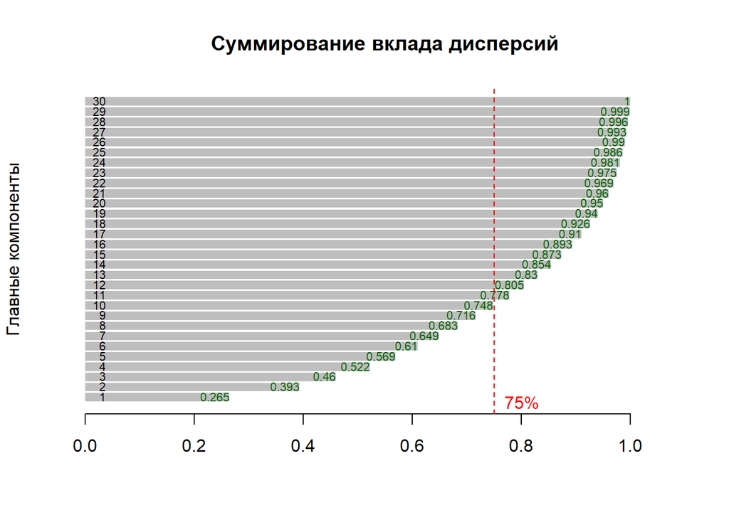

```r
myplot <- barplot(histogram, xlim = c(0, 1.1), border = NA, ylab = "Главные компоненты", main = "Cуммирование вклада дисперсий", horiz = T)
text(y = myplot, x = histogram, label = histogram,  col = "darkgreen", pos = 2, offset = 0, cex = 0.7)
text(y = myplot, x = 0, cex = 0.7, pos = 2, offset = -1)
abline(v = 0.75, col = "red", lty = 2)
text(0.75, 0, "75%", pos=4, col = "red")
```

**Показать, какие признаки вносят наибольший вклад в те первые главные компоненты, которые описывают 75% дисперсии данных.**  
В нашем случае 77.8% вклада дают первые 11 компонент:

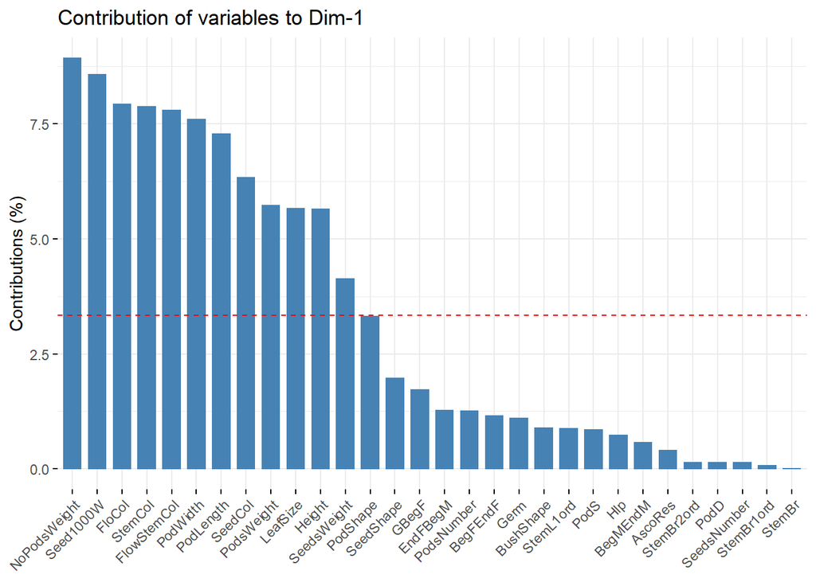

```r
fviz_contrib(df_pca, choice = "var", axes = 1)
```

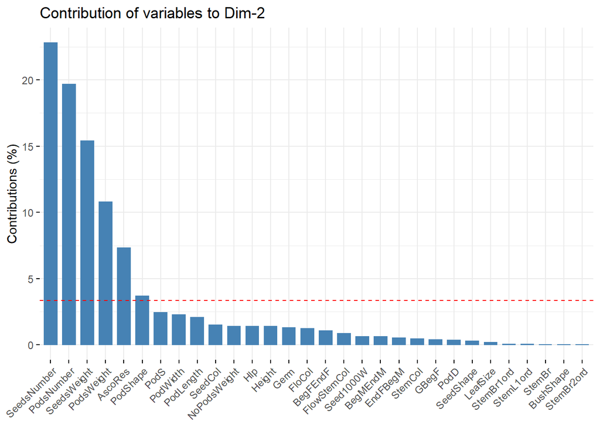

```r
fviz_contrib(df_pca, choice = "var", axes = 2)
```

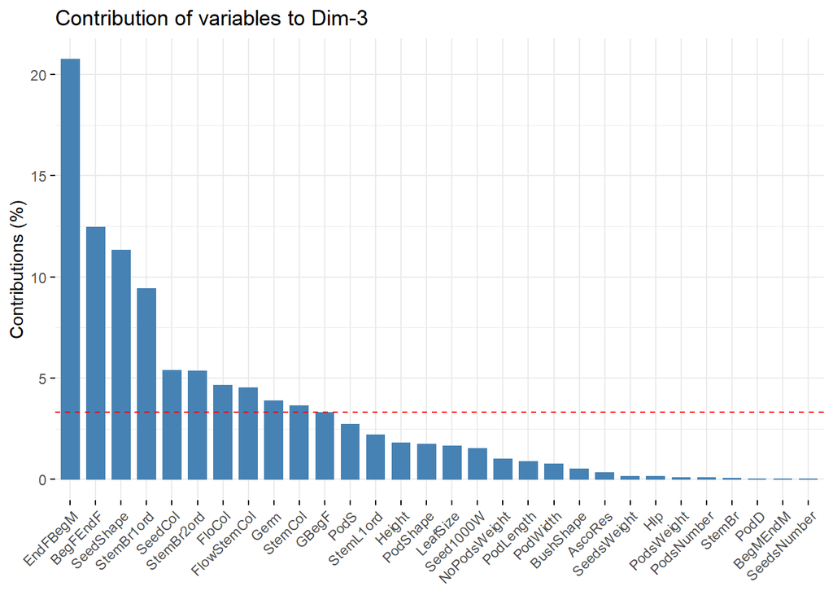

```r
fviz_contrib(df_pca, choice = "var", axes = 3)
```

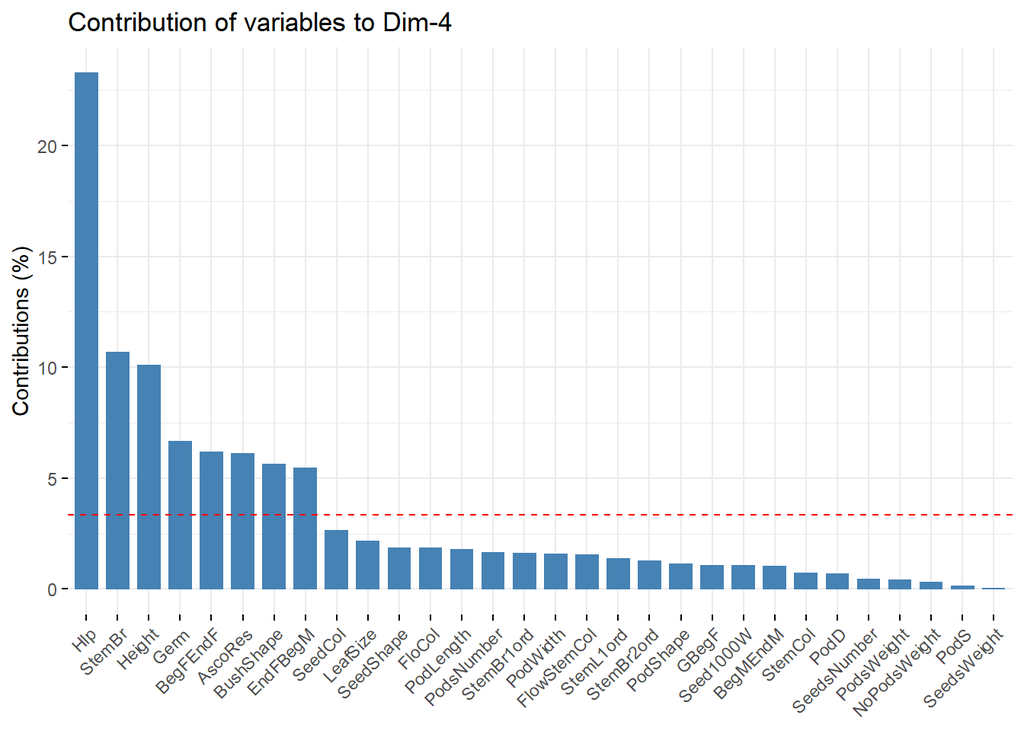

```r
fviz_contrib(df_pca, choice = "var", axes = 4)
```

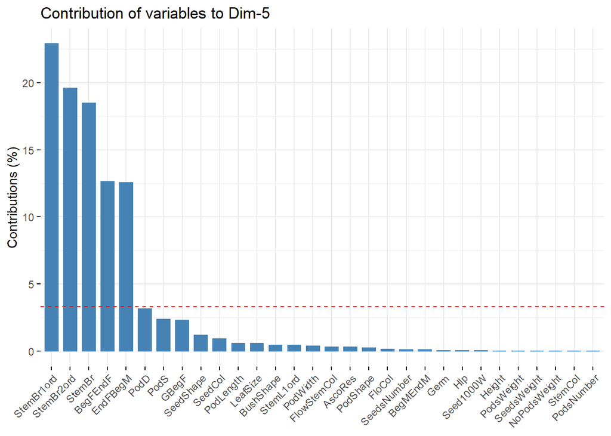

```r
fviz_contrib(df_pca, choice = "var", axes = 5)
```

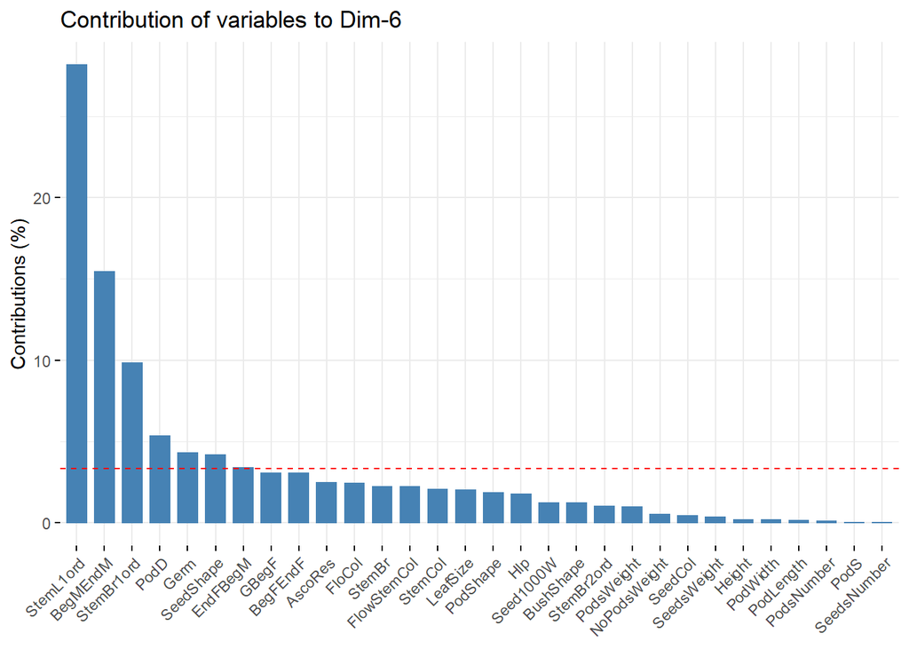

```r
fviz_contrib(df_pca, choice = "var", axes = 6)
```

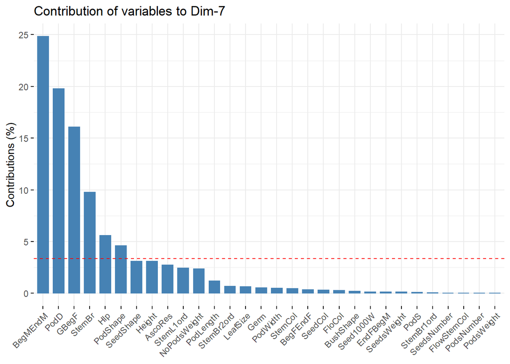

```r
fviz_contrib(df_pca, choice = "var", axes = 7)
```

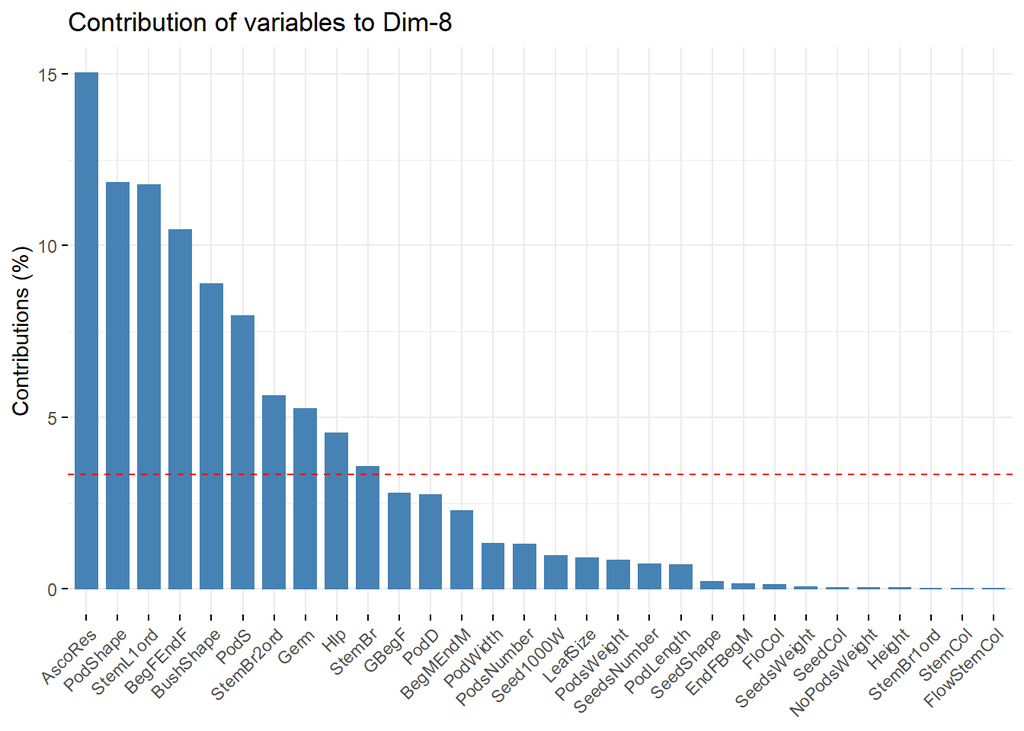

```r
fviz_contrib(df_pca, choice = "var", axes = 8)
```

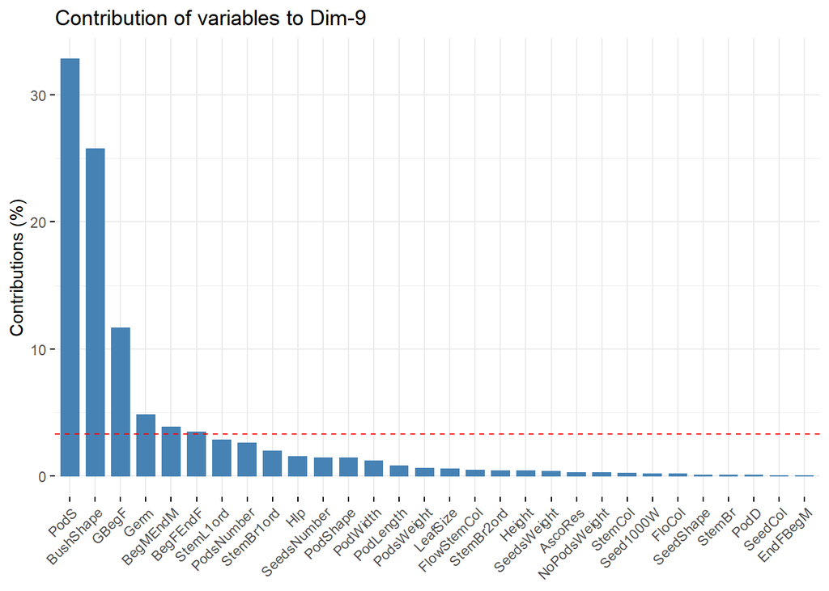

```r
fviz_contrib(df_pca, choice = "var", axes = 9)
```

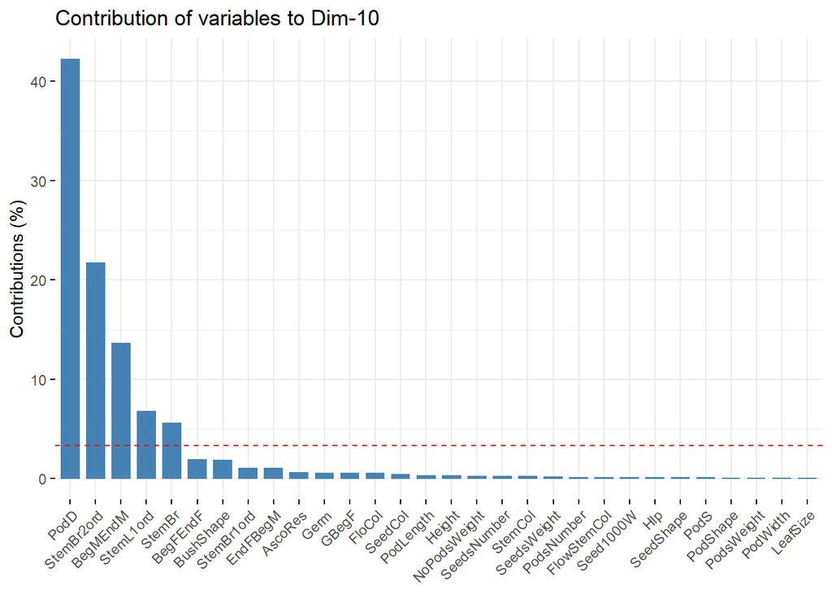

```r
fviz_contrib(df_pca, choice = "var", axes = 10)
```

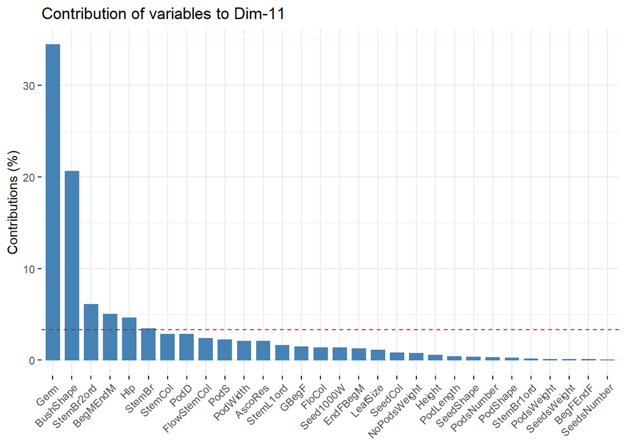

```r
fviz_contrib(df_pca, choice = "var", axes = 11)
```

**Отобразить данные на плоскости первых 2х главных компонент. Обозначить цветом значения качественного признака, который входит в первую главную компоненту с наибольшим весом.**

Вручную отсортируем веса для первой главной компоненты:

```r
sort(abs(df_pca$rotation[,1]), decreasing = T)
```

```
## NoPodsWeight    Seed1000W       FloCol      StemCol  FlowStemCol     PodWidth
##  0.298792544  0.292598231  0.281523264  0.280560722  0.279081315  0.275482237
##    PodLength      SeedCol   PodsWeight     LeafSize       Height  SeedsWeight
##  0.269776923  0.251632217  0.239194646  0.237875910  0.237481874  0.203027731
##     PodShape    SeedShape        GBegF     EndFBegM   PodsNumber     BegFEndF
##  0.181968591  0.140372945  0.131122373  0.112732179  0.112245976  0.107532341
##         Germ    BushShape    StemL1ord         PodS          Hlp     BegMEndM
##  0.104730439  0.094078738  0.093671677  0.092310205  0.085561513  0.075822039
##      AscoRes   StemBr2ord         PodD  SeedsNumber   StemBr1ord       StemBr
##  0.062821157  0.036928248  0.036761059  0.036262292  0.027102830  0.008408691
```

Видим, что наибольший вклад из качественных признаков вносит FloCol.  
Отобразим эти данные на плоскости первых двух главных компонент:

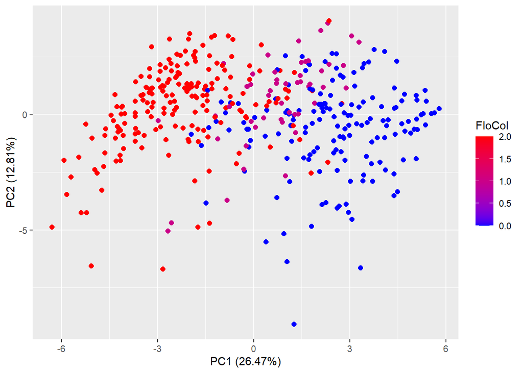

```r
ggplot(pca_cut, aes(x=PC1, y=PC2, color = abs(df$FloCol))) +
  geom_point(size = 2) +
  scale_color_gradient(low="blue", high="red", name = "FloCol") +
  labs(x=paste(sep = "", "PC1 (", format(dispersion[1]*100, digits = 4), "%)"),
       y=paste(sep = "", "PC2 (", format(dispersion[2]*100, digits = 4), "%)"))
```